# Car fuels — diesel: weekly BVAR-SV-outlier

> **Data contract.** This notebook reads only the model-ready CSV under `data/processed/<vintage>/`. The single raw Excel workbook is handled upstream by the dataset builder; changing source tickers does not require notebook code changes as long as the processed canonical columns remain available.

This notebook estimates the **diesel** weekly sub-model of the euro-area energy-inflation suite. The endogenous block contains weekly absolute changes in the WOB diesel pre-tax price, crude oil and refined diesel prices. The model uses **24 weekly lags**, stochastic volatility and model-based transitory outliers.

$$ y_t = c + \sum_{\ell=1}^{24} B_\ell y_{t-\ell} + \nu_t, \qquad \nu_t=A^{-1}O_t\Lambda_t^{1/2}\varepsilon_t. $$

## 1. Imports and configuration

```python
from pathlib import Path
import sys

import numpy as np
import pandas as pd
import matplotlib.pyplot as plt
from IPython.display import display

def find_project_root(start: Path) -> Path:
    start = start.resolve()
    for candidate in [start, *start.parents]:
        if (candidate / "data").exists() or (candidate / "src").exists():
            return candidate
    return start

PROJECT_ROOT = find_project_root(Path.cwd())
MODEL_DIR_CANDIDATES = [
    PROJECT_ROOT / "src" / "model",
    PROJECT_ROOT,
    Path.cwd(),
]
for candidate in MODEL_DIR_CANDIDATES:
    required_modules = (
        "energy_bvar_model.py",
        "energy_bvar_weekly_fuels.py",
        "energy_bvar_plot.py",
        "energy_bvar_io.py",
    )
    if all((candidate / name).exists() for name in required_modules):
        sys.path.insert(0, str(candidate))
        MODEL_DIR = candidate
        break
else:
    raise FileNotFoundError(
        "Place energy_bvar_model.py, energy_bvar_weekly_fuels.py, "
        "energy_bvar_plot.py and energy_bvar_io.py in src/model/."
    )

from energy_bvar_model import (
    BVARSVOPriorConfig,
    SamplerConfig,
    coefficient_posterior_tables,
    forecast_bvar_sv_outlier,
    forecast_error_variance_decomposition,
    historical_decomposition,
    impulse_responses,
    make_bvar_svo_prior,
    mcmc_diagnostics,
    nowcast_summary_table,
    posterior_outlier_probability,
    posterior_predictive_statistics,
    posterior_completed_differences,
    prepare_bvar_panel,
    residual_diagnostic_table,
    run_energy_bvar,
    stability_diagnostics,
    stationarity_tests,
)
from energy_bvar_io import (
    save_energy_bvar_result,
    save_energy_bvar_forecast_for_result,
)
from energy_bvar_weekly_fuels import (
    load_weekly_fuel_panel,
    load_weekly_tax_context,
    reattribute_weekly_taxes,
    weekly_forecast_horizon_table,
    weekly_fuel_series_construction_table,
    weekly_partial_period_table,
    weekly_fuel_spec,
    weekly_paths_to_monthly_mean,
)
from energy_bvar_plot import (
    plot_absolute_differences,
    plot_chain_acf_grid,
    plot_coefficient_heatmap,
    plot_data_levels,
    plot_fevd,
    plot_forecast_comparison,
    tax_inflation_spread_table,
    tax_scenario_effect_summary_table,
    plot_tax_assumptions,
    plot_tax_scenario_impact,
    plot_tax_level_and_inflation_impact,
    plot_historical_decomposition,
    plot_impulse_responses,
    plot_minnesota_prior_by_equation,
    plot_nowcast_fan,
    plot_phi_and_outlier_priors,
    plot_posterior_predictive_check,
    plot_short_forecast_fan,
    plot_shrinkage_comparison,
    plot_spectral_radius,
    plot_standardized_residuals,
    plot_trace_grid,
    plot_volatility_decomposition,
    style_numeric_table,
)

plt.rcParams.update({
    "figure.dpi": 120,
    "axes.titlesize": 11,
    "axes.labelsize": 10,
    "legend.fontsize": 9,
})

MODEL = "diesel"
SPEC = weekly_fuel_spec(MODEL)
COMPONENT = "car_fuels_diesel"
SEED = 42
P = 24
MISSING_DATA_METHOD = "linear"  # "linear" = fast approximation; "dk" = exact interior-missing treatment
SIMULATE_FUTURE_OUTLIERS = True
CODE_VERSION = "energy_bvar_model-v2"
VARIABLES = SPEC["variables"]
TARGET = SPEC["target"]
UNITS = SPEC["units"]
SAVE_RESULTS = False      # heavy Gibbs cache
SAVE_FORECASTS = True     # lightweight predictive store for Notebook 10
RESULTS_ROOT = PROJECT_ROOT / "results"

FORECAST_H = 26
FORECAST_DRAWS = 500
PPC_DRAWS = 200
STRUCTURAL_DRAWS = 300
```

## 2. Data

### Missing-data treatment used in this notebook

`MISSING_DATA_METHOD = "linear"` is the fast default. Bounded interior missing **levels** are interpolated once; these pseudo-observations then enter the likelihood as fixed values. Set `MISSING_DATA_METHOD = "dk"` to propagate uncertainty about interior gaps through the Gibbs sampler. In both modes, the ragged edge and future conditional paths are handled by Durbin–Koopman state-space simulation. The result metadata and forecast-table/plot labels surface whether an approximation was actually used.

```
Dataset: C:\Users\kelyan.gane\Project\Python\Bayesian_model\bvar-energy\data\processed\20260808\car_fuels_weekly.csv
Sample calendar: 2005-01-03 to 2026-08-10
Rows: 1,128; all dates Monday: True
```

Construction of the weekly diesel-model level series

| series | model_unit | source | construction | weekly_alignment | commodity_shift_weeks |
| --- | --- | --- | --- | --- | --- |
| wob_diesel_pre_tax | EUR per 1,000 litres | European Commission Weekly Oil Bulletin | Official pre-tax consumer price, Monday observation | Monday WOB date | — |
| crude_oil_eur | EUR per barrel | Bloomberg crude oil and EUR/USD | Daily USD/barrel converted to EUR/barrel, then weekly mean | shift=1 aligns WOB Monday t with the preceding completed Monday-Sunday commodity week; shift=0 uses the same week. | 1.00 |
| refined_diesel_eur | EUR per barrel | Bloomberg refined-diesel future and EUR/USD | Daily USD/metric-tonne quote converted with 7.44 barrels per tonne and EUR/USD, then weekly mean | shift=1 aligns WOB Monday t with the preceding completed Monday-Sunday commodity week; shift=0 uses the same week. | 1.00 |

Final-period aggregation coverage (builder sidecar)

|  | series | panel_column | panel_label_date | final_period_input_observations | expected_input_observations | coverage_ratio | final_period_complete | first_input_date | last_input_date |
| --- | --- | --- | --- | --- | --- | --- | --- | --- | --- |
| 0 | crude_oil_eur | crude_oil_eur | 2026-08-10 | 5.00 | 5.00 | 1.00 | 1.00 | 2026-08-03 | 2026-08-07 |
| 1 | refined_diesel_eur | refined_diesel_eur | 2026-08-10 | 5.00 | 5.00 | 1.00 | 1.00 | 2026-08-03 | 2026-08-07 |

Latest processed weekly levels after adapter masking

| date | wob_diesel_pre_tax | crude_oil_eur | refined_diesel_eur |
| --- | --- | --- | --- |
| 2026-05-25 | 1136.63 | 88.76 | 136.98 |
| 2026-06-01 | 1095.59 | 79.94 | 120.93 |
| 2026-06-08 | 1068.50 | 81.79 | 125.90 |
| 2026-06-15 | 1047.33 | 78.66 | 119.73 |
| 2026-06-22 | 984.54 | 69.32 | 105.08 |
| 2026-06-29 | 972.50 | 66.19 | 104.76 |
| 2026-07-06 | 964.24 | 64.07 | 109.26 |
| 2026-07-13 | 1017.49 | 66.34 | 120.74 |
| 2026-07-20 | 1103.26 | 74.34 | 133.77 |
| 2026-07-27 | 1170.53 | 79.50 | 145.36 |
| 2026-08-03 | 1214.88 | 76.02 | 149.78 |
| 2026-08-10 | — | 70.37 | 136.68 |

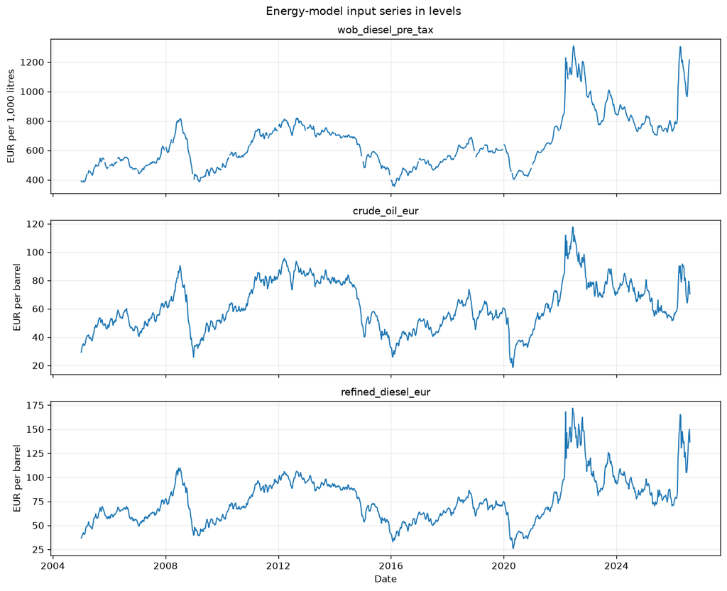

```python
# Set VINTAGE = "YYYYMMDD" to force one processed vintage.
VINTAGE = None
PROCESSED_ROOT = PROJECT_ROOT / "data" / "processed"

if VINTAGE is None:
    candidates = sorted(
        path
        for path in PROCESSED_ROOT.glob(f"*/{SPEC['dataset']}")
        if path.is_file()
    )
    if not candidates:
        raise FileNotFoundError(
            f"No {SPEC['dataset']} found below {PROCESSED_ROOT}."
        )
    COMPONENT_DATASET = candidates[-1]
else:
    COMPONENT_DATASET = PROCESSED_ROOT / VINTAGE / SPEC["dataset"]

levels = load_weekly_fuel_panel(COMPONENT_DATASET, model=MODEL)

print(f"Dataset: {COMPONENT_DATASET}")
print(f"Sample calendar: {levels.index.min().date()} to {levels.index.max().date()}")
print(f"Rows: {len(levels):,}; all dates Monday: {(levels.index.dayofweek == 0).all()}")

display(style_numeric_table(
    weekly_fuel_series_construction_table(COMPONENT_DATASET, MODEL),
    caption="Construction of the weekly diesel-model level series",
))
coverage_table = weekly_partial_period_table(COMPONENT_DATASET, MODEL)
if not coverage_table.empty:
    display(style_numeric_table(
        coverage_table,
        caption="Final-period aggregation coverage (builder sidecar)",
    ))

partial_mask = levels.attrs.get("partial_period_mask", pd.DataFrame())
if isinstance(partial_mask, pd.DataFrame) and not partial_mask.empty:
    display(style_numeric_table(
        partial_mask,
        caption="Partial final aggregates masked to NaN before BVAR estimation",
    ))

display(style_numeric_table(
    levels.tail(12),
    caption="Latest processed weekly levels after adapter masking",
))
plot_data_levels(levels, units=UNITS)
plt.show()
```

The endogenous vector is ordered from the consumer price upstream through the commodity chain:

$$ y_t= \begin{bmatrix} \Delta P_t^{\mathrm{diesel,pre\ tax}}\\ \Delta P_t^{\mathrm{crude}}\\ \Delta P_t^{\mathrm{refined\ diesel}} \end{bmatrix}, \qquad \Delta x_t=x_t-x_{t-1}. $$

Transformation and estimation sample

|  | value |
| --- | --- |
| missing_data_method | linear |
| missing_treatment_exact | False |
| interpolated_level_cells | 49 |
| frequency | weekly |
| calendar_rule | W-MON |
| estimation_mode | balanced sample |
| companion_warmup_start | 2005-01-10 00:00:00 |
| augmentation_anchor | not required |
| estimation_end | 2026-08-03 00:00:00 |
| VAR_regression_observations | 1102 |
| regression_columns_per_equation | 73 |
| interior_missing_dates | 0 |
| interior_missing_level_cells | 0 |
| ragged_edge_weeks | 1 |
| latest_calendar_week | 2026-08-10 00:00:00 |

Ragged-edge absolute weekly changes

| date | wob_diesel_pre_tax | crude_oil_eur | refined_diesel_eur |
| --- | --- | --- | --- |
| 2026-08-10 | — | -5.65 | -13.10 |

Linear interpolation audit — first imputed interior levels

| date | variable | linear_imputation |
| --- | --- | --- |
| 2005-01-03 | wob_diesel_pre_tax | — |
|  | crude_oil_eur | — |
|  | refined_diesel_eur | — |
| 2005-01-10 | wob_diesel_pre_tax | — |
|  | crude_oil_eur | — |
|  | refined_diesel_eur | — |
| 2005-01-17 | wob_diesel_pre_tax | — |
|  | crude_oil_eur | — |
|  | refined_diesel_eur | — |
| 2005-01-24 | wob_diesel_pre_tax | — |
|  | crude_oil_eur | — |
|  | refined_diesel_eur | — |
| 2005-01-31 | wob_diesel_pre_tax | — |
|  | crude_oil_eur | — |
|  | refined_diesel_eur | — |
| 2005-02-07 | wob_diesel_pre_tax | — |
|  | crude_oil_eur | — |
|  | refined_diesel_eur | — |
| 2005-02-14 | wob_diesel_pre_tax | — |
|  | crude_oil_eur | — |
|  | refined_diesel_eur | — |
| 2005-02-21 | wob_diesel_pre_tax | — |
|  | crude_oil_eur | — |
|  | refined_diesel_eur | — |
| 2005-02-28 | wob_diesel_pre_tax | — |
|  | crude_oil_eur | — |
|  | refined_diesel_eur | — |
| 2005-03-07 | wob_diesel_pre_tax | — |
|  | crude_oil_eur | — |
|  | refined_diesel_eur | — |

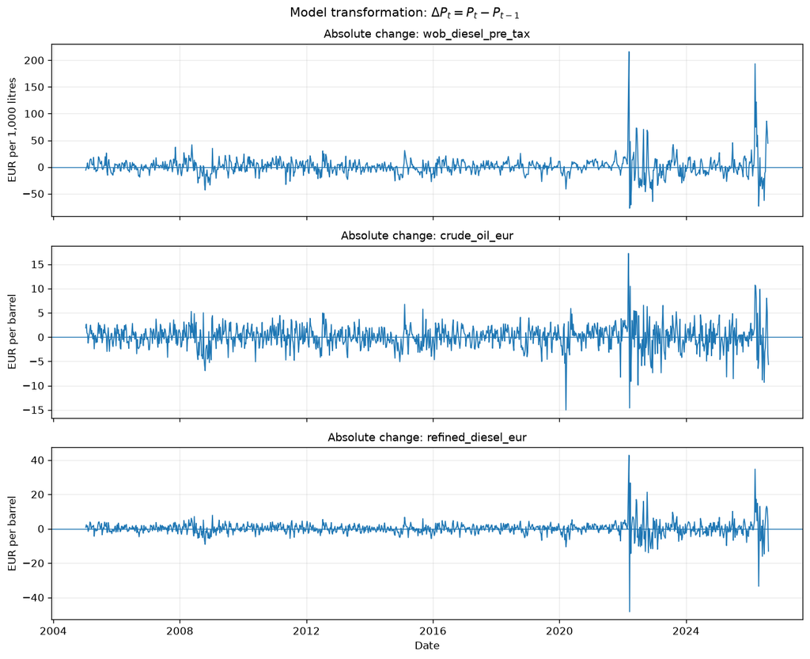

```python
prep = prepare_bvar_panel(
    levels,
    p=P,
    variables=VARIABLES,
    frequency="weekly",
    missing_data_method=MISSING_DATA_METHOD,
)

transformation_summary = pd.Series({
    "missing_data_method": prep["missing_data_method"],
    "missing_treatment_exact": prep["missing_treatment_exact"],
    "interpolated_level_cells": prep["n_interpolated_level_cells"],
    "frequency": prep["frequency"],
    "calendar_rule": prep["calendar_rule"],
    "estimation_mode": (
        "Durbin-Koopman interior data augmentation"
        if prep.get("requires_data_augmentation", False)
        else "balanced sample"
    ),
    "companion_warmup_start": prep["balanced_start"],
    "augmentation_anchor": prep.get("augmentation_anchor", "not required"),
    "estimation_end": prep["balanced_end"],
    "VAR_regression_observations": prep["n_regression_observations"],
    "regression_columns_per_equation": prep["k"],
    "interior_missing_dates": prep.get("n_interior_missing_dates", 0),
    "interior_missing_level_cells": prep.get("n_interior_missing_level_cells", 0),
    "ragged_edge_weeks": prep["n_ragged_periods"],
    "latest_calendar_week": prep["last_calendar_date"],
})
display(style_numeric_table(
    transformation_summary.to_frame("value"),
    caption="Transformation and estimation sample",
))

if prep.get("requires_data_augmentation", False):
    missing_dates = pd.DataFrame({
        "date": prep["interior_missing_dates"],
    }).set_index("date")
    display(style_numeric_table(
        missing_dates,
        caption="Interior weeks entering the Gibbs sampler as latent states",
    ))

display(style_numeric_table(
    prep["ragged"],
    caption="Ragged-edge absolute weekly changes",
))

if prep.get("n_interpolated_level_cells", 0):
    linear_imputation = (
        prep["levels"]
        .where(prep["interpolated_level_mask"])
        .stack()
        .rename("linear_imputation")
        .to_frame()
    )
    linear_imputation.index.names = ["date", "variable"]
    display(style_numeric_table(
        linear_imputation.head(30),
        caption="Linear interpolation audit — first imputed interior levels",
    ))

plot_absolute_differences(prep["differences"], units=UNITS)
plt.show()
```

## 3. Priors

Prior hyperparameters

|  | value | interpretation |
| --- | --- | --- |
| lambda1 | 0.20 | overall Minnesota lag tightness |
| lambda2 | 0.50 | additional cross-lag tightness |
| lambda3 | 1.00 | lag-decay exponent |
| lambda4 | 10.00 | constant prior scale |
| A prior variance | 10.00 | variance of each free contemporaneous A coefficient |
| phi prior mean | 0.02 | prior mean of volatility-of-volatility variance |
| outlier alpha | 2.50 | Beta outlier pseudo-count |
| outlier beta | 117.50 | Beta regular-observation pseudo-count |

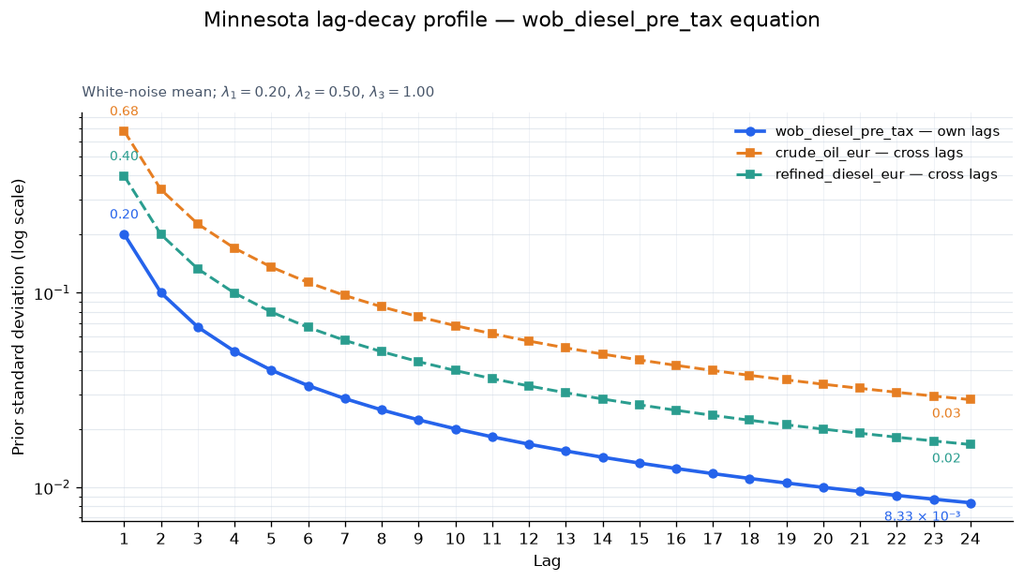

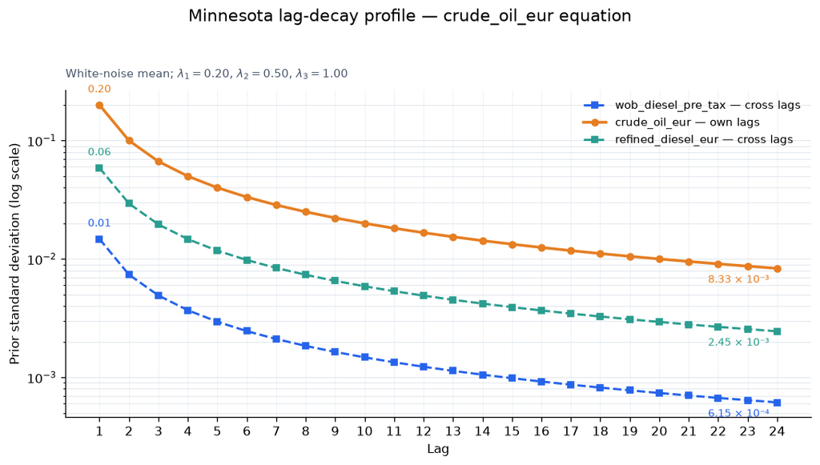

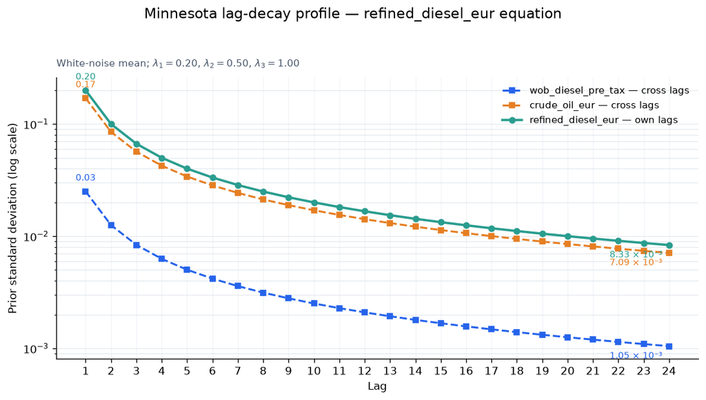

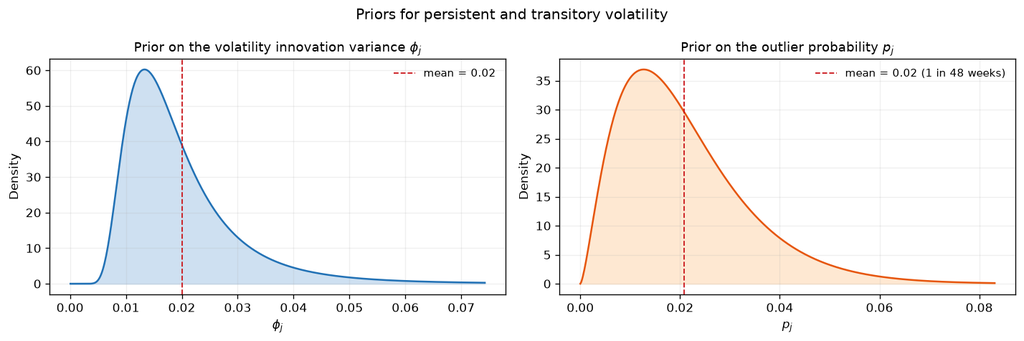

```python
prior_config = BVARSVOPriorConfig(
    lambda1=0.20,
    lambda2=0.50,
    lambda3=1.00,
    lambda4=10.0,
    a_prior_var=10.0,
    phi_prior_mean=0.02,
    phi_prior_df=10.0,
    h0_var=4.0,
    outlier_mean_frequency=1.0 / 48.0,
    outlier_prior_observations=120.0,
    outlier_grid_min=2.0,
    outlier_grid_max=20.0,
    outlier_grid_step=1.0,
    ksc_offset_scale=1e-6,
)
prior = make_bvar_svo_prior(prep, prior_config)

prior_table = pd.DataFrame({
    "value": [
        prior_config.lambda1,
        prior_config.lambda2,
        prior_config.lambda3,
        prior_config.lambda4,
        prior_config.a_prior_var,
        prior_config.phi_prior_mean,
        prior["outlier_alpha"],
        prior["outlier_beta"],
    ],
    "interpretation": [
        "overall Minnesota lag tightness",
        "additional cross-lag tightness",
        "lag-decay exponent",
        "constant prior scale",
        "variance of each free contemporaneous A coefficient",
        "prior mean of volatility-of-volatility variance",
        "Beta outlier pseudo-count",
        "Beta regular-observation pseudo-count",
    ],
}, index=[
    "lambda1", "lambda2", "lambda3", "lambda4",
    "A prior variance", "phi prior mean",
    "outlier alpha", "outlier beta",
])
display(style_numeric_table(prior_table, caption="Prior hyperparameters"))

prior_figures = plot_minnesota_prior_by_equation(prior, VARIABLES, P)
for equation, figure in prior_figures.items():
    display(figure)
    plt.close(figure)
plot_phi_and_outlier_priors(prior)
plt.show()
```

## 4. Posterior and Gibbs sampler

```python
sampler_config = SamplerConfig(
    reps=6_000,
    burn=3_000,
    thin=1,
    seed=SEED,
    max_stability_tries=1_000,
    progress_every=500,
    dk_projection_mode="strict",
    dk_level_relative_gate=1e-6,
    dk_difference_relative_gate=1e-6,
)

result = run_energy_bvar(
    levels=levels,
    model_id=COMPONENT,
    vintage=COMPONENT_DATASET.parent.name,
    p=P,
    variables=VARIABLES,
    frequency="weekly",
    prior_config=prior_config,
    sampler_config=sampler_config,
    missing_data_method=MISSING_DATA_METHOD,
    code_version=CODE_VERSION,
)

print(f"Retained posterior draws: {result['n_draws']:,}")
print(f"Run ID: {result['metadata']['run_id']}")
print(f"Missing-data method: {result['metadata']['missing_data_method']}")
print(f"Exact missing-data treatment: {result['metadata']['missing_treatment_exact']}")
print(f"Interpolated level cells: {result['metadata']['interpolated_level_cells']}")
print(f"Frequency: {result['metadata']['frequency']}")
print(f"Data augmentation: {result['metadata'].get('data_augmentation', 'none')}")
print(
    "B instability proposal rejection rate: "
    f"{result['B_instability_rejection_rate']:.2%}"
)
display(style_numeric_table(
    pd.Series(dict(zip(VARIABLES, result["ksc_offsets"]))).to_frame("KSC offset"),
    caption="Adaptive KSC offsets",
))

dk_diag = result.get("dk_projection_diagnostics", {})
if dk_diag:
    print(
        "DK projection max relative errors: "
        f"level={dk_diag.get('level_error', {}).get('max', np.nan):.3e}, "
        f"difference={dk_diag.get('difference_adjustment', {}).get('max', np.nan):.3e}"
    )

if SAVE_RESULTS:
    saved_result_paths = save_energy_bvar_result(result, RESULTS_ROOT)
    print(f"Saved run: {saved_result_paths['directory']}")
```

```
iteration 500/6,000 | B instability rejection 0.00% | radius 0.8797
iteration 1,000/6,000 | B instability rejection 0.00% | radius 0.8792
iteration 1,500/6,000 | B instability rejection 0.00% | radius 0.8778
iteration 2,000/6,000 | B instability rejection 0.00% | radius 0.8899
iteration 2,500/6,000 | B instability rejection 0.00% | radius 0.8640
iteration 3,000/6,000 | B instability rejection 0.00% | radius 0.9051
iteration 3,500/6,000 | B instability rejection 0.00% | radius 0.8704
iteration 4,000/6,000 | B instability rejection 0.00% | radius 0.8918
iteration 4,500/6,000 | B instability rejection 0.00% | radius 0.8981
iteration 5,000/6,000 | B instability rejection 0.00% | radius 0.8734
iteration 5,500/6,000 | B instability rejection 0.00% | radius 0.8786
iteration 6,000/6,000 | B instability rejection 0.00% | radius 0.8858
Retained posterior draws: 3,000
Run ID: aae4c3189fe304e9b1d5e043ea6653dc07a38bdb89b41b044c8315d5f274217d
Missing-data method: linear
Exact missing-data treatment: False
Interpolated level cells: 49
Frequency: weekly
Data augmentation: linear_interpolation
B instability proposal rejection rate: 0.00%
```

Adaptive KSC offsets

|  | KSC offset |
| --- | --- |
| wob_diesel_pre_tax | 3.90 × 10⁻⁵ |
| crude_oil_eur | 1.62 × 10⁻⁶ |
| refined_diesel_eur | 2.78 × 10⁻⁶ |

## 5. Posterior results

```
wob_diesel_pre_tax equation
```

Posterior coefficients — wob_diesel_pre_tax equation

| regressor | prior_mean | prior_sd | posterior_mean | posterior_median | posterior_sd | q05 | q16 | q84 | q95 | ESS |
| --- | --- | --- | --- | --- | --- | --- | --- | --- | --- | --- |
| const | 0.00 | 164.29 | 0.25 | 0.25 | 0.24 | -0.15 | 0.01 | 0.49 | 0.64 | 1647.17 |
| wob_diesel_pre_tax L1 | 0.00 | 0.20 | 0.06 | 0.06 | 0.04 | -0.01 | 0.01 | 0.10 | 0.13 | 1380.01 |
| crude_oil_eur L1 | 0.00 | 0.68 | 0.85 | 0.85 | 0.21 | 0.51 | 0.64 | 1.07 | 1.21 | 114.74 |
| refined_diesel_eur L1 | 0.00 | 0.40 | 1.42 | 1.43 | 0.19 | 1.10 | 1.23 | 1.61 | 1.75 | 566.13 |
| wob_diesel_pre_tax L2 | 0.00 | 0.10 | 0.01 | 0.01 | 0.03 | -0.04 | -0.02 | 0.05 | 0.06 | 2204.87 |
| crude_oil_eur L2 | 0.00 | 0.34 | -0.18 | -0.18 | 0.16 | -0.44 | -0.34 | -0.02 | 0.08 | 1316.00 |
| refined_diesel_eur L2 | 0.00 | 0.20 | 0.44 | 0.44 | 0.14 | 0.21 | 0.30 | 0.57 | 0.65 | 315.49 |
| wob_diesel_pre_tax L3 | 0.00 | 0.07 | 2.45 × 10⁻³ | 2.71 × 10⁻³ | 0.03 | -0.04 | -0.02 | 0.03 | 0.05 | 2250.36 |
| crude_oil_eur L3 | 0.00 | 0.23 | 0.12 | 0.12 | 0.13 | -0.09 | -8.22 × 10⁻³ | 0.25 | 0.33 | 2631.90 |
| refined_diesel_eur L3 | 0.00 | 0.13 | 0.17 | 0.16 | 0.10 | -9.84 × 10⁻⁴ | 0.06 | 0.27 | 0.33 | 2219.16 |
| wob_diesel_pre_tax L4 | 0.00 | 0.05 | -0.03 | -0.03 | 0.02 | -0.07 | -0.06 | -8.81 × 10⁻³ | 5.37 × 10⁻³ | 1596.94 |
| crude_oil_eur L4 | 0.00 | 0.17 | 0.18 | 0.18 | 0.11 | -3.81 × 10⁻³ | 0.07 | 0.29 | 0.36 | 2004.13 |
| refined_diesel_eur L4 | 0.00 | 0.10 | -3.46 × 10⁻³ | -2.24 × 10⁻³ | 0.08 | -0.14 | -0.09 | 0.08 | 0.13 | 2529.67 |
| wob_diesel_pre_tax L5 | 0.00 | 0.04 | -0.02 | -0.02 | 0.02 | -0.06 | -0.04 | -2.13 × 10⁻³ | 0.01 | 2548.72 |
| crude_oil_eur L5 | 0.00 | 0.14 | 0.23 | 0.23 | 0.09 | 0.08 | 0.14 | 0.33 | 0.39 | 2529.81 |
| refined_diesel_eur L5 | 0.00 | 0.08 | 0.07 | 0.07 | 0.07 | -0.04 | 8.89 × 10⁻⁴ | 0.14 | 0.18 | 2752.37 |
| wob_diesel_pre_tax L6 | 0.00 | 0.03 | 0.02 | 0.02 | 0.02 | -0.01 | -2.43 × 10⁻³ | 0.04 | 0.05 | 1207.77 |
| crude_oil_eur L6 | 0.00 | 0.11 | 0.04 | 0.04 | 0.09 | -0.10 | -0.05 | 0.13 | 0.18 | 2347.46 |
| refined_diesel_eur L6 | 0.00 | 0.07 | 0.04 | 0.04 | 0.06 | -0.06 | -0.02 | 0.10 | 0.14 | 3000.00 |
| wob_diesel_pre_tax L7 | 0.00 | 0.03 | 0.02 | 0.02 | 0.02 | -0.01 | -1.32 × 10⁻³ | 0.03 | 0.05 | 2266.14 |
| crude_oil_eur L7 | 0.00 | 0.10 | 5.63 × 10⁻³ | 5.55 × 10⁻³ | 0.08 | -0.12 | -0.07 | 0.08 | 0.13 | 2320.54 |
| refined_diesel_eur L7 | 0.00 | 0.06 | 0.01 | 9.54 × 10⁻³ | 0.05 | -0.07 | -0.04 | 0.06 | 0.10 | 2595.85 |
| wob_diesel_pre_tax L8 | 0.00 | 0.03 | -2.35 × 10⁻³ | -2.11 × 10⁻³ | 0.02 | -0.03 | -0.02 | 0.01 | 0.02 | 1795.61 |
| crude_oil_eur L8 | 0.00 | 0.08 | 2.11 × 10⁻³ | 3.17 × 10⁻³ | 0.07 | -0.11 | -0.07 | 0.07 | 0.11 | 2509.40 |
| refined_diesel_eur L8 | 0.00 | 0.05 | 0.01 | 0.01 | 0.05 | -0.06 | -0.04 | 0.06 | 0.08 | 2675.71 |
| wob_diesel_pre_tax L9 | 0.00 | 0.02 | -0.01 | -9.82 × 10⁻³ | 0.02 | -0.04 | -0.03 | 5.24 × 10⁻³ | 0.02 | 1449.11 |
| crude_oil_eur L9 | 0.00 | 0.08 | 0.04 | 0.04 | 0.06 | -0.06 | -0.02 | 0.10 | 0.14 | 2632.20 |
| refined_diesel_eur L9 | 0.00 | 0.04 | -0.02 | -0.02 | 0.04 | -0.08 | -0.06 | 0.02 | 0.05 | 2776.74 |
| wob_diesel_pre_tax L10 | 0.00 | 0.02 | -0.02 | -0.02 | 0.01 | -0.05 | -0.04 | -9.74 × 10⁻³ | -4.77 × 10⁻⁴ | 2432.69 |
| crude_oil_eur L10 | 0.00 | 0.07 | 0.01 | 0.01 | 0.06 | -0.08 | -0.04 | 0.07 | 0.10 | 2445.48 |
| refined_diesel_eur L10 | 0.00 | 0.04 | 4.15 × 10⁻³ | 3.51 × 10⁻³ | 0.04 | -0.06 | -0.03 | 0.04 | 0.07 | 2883.19 |
| wob_diesel_pre_tax L11 | 0.00 | 0.02 | 2.26 × 10⁻³ | 2.34 × 10⁻³ | 0.01 | -0.02 | -0.01 | 0.02 | 0.02 | 2434.59 |
| crude_oil_eur L11 | 0.00 | 0.06 | 6.88 × 10⁻³ | 6.32 × 10⁻³ | 0.05 | -0.08 | -0.05 | 0.06 | 0.09 | 2902.90 |
| refined_diesel_eur L11 | 0.00 | 0.04 | -4.03 × 10⁻³ | -4.26 × 10⁻³ | 0.03 | -0.06 | -0.04 | 0.03 | 0.05 | 2666.00 |
| wob_diesel_pre_tax L12 | 0.00 | 0.02 | 0.03 | 0.03 | 0.01 | 5.08 × 10⁻³ | 0.01 | 0.04 | 0.05 | 2620.97 |
| crude_oil_eur L12 | 0.00 | 0.06 | -0.02 | -0.02 | 0.05 | -0.11 | -0.07 | 0.03 | 0.06 | 2693.57 |
| refined_diesel_eur L12 | 0.00 | 0.03 | 6.09 × 10⁻³ | 6.78 × 10⁻³ | 0.03 | -0.05 | -0.03 | 0.04 | 0.06 | 2823.54 |
| wob_diesel_pre_tax L13 | 0.00 | 0.02 | -6.37 × 10⁻³ | -6.17 × 10⁻³ | 0.01 | -0.03 | -0.02 | 5.55 × 10⁻³ | 0.01 | 2794.49 |
| crude_oil_eur L13 | 0.00 | 0.05 | -0.02 | -0.02 | 0.05 | -0.10 | -0.07 | 0.02 | 0.05 | 2940.40 |
| refined_diesel_eur L13 | 0.00 | 0.03 | -2.40 × 10⁻³ | -3.24 × 10⁻³ | 0.03 | -0.05 | -0.03 | 0.03 | 0.05 | 2579.89 |
| wob_diesel_pre_tax L14 | 0.00 | 0.01 | -8.25 × 10⁻³ | -8.32 × 10⁻³ | 0.01 | -0.03 | -0.02 | 2.93 × 10⁻³ | 0.01 | 2753.60 |
| crude_oil_eur L14 | 0.00 | 0.05 | 3.98 × 10⁻⁴ | 9.31 × 10⁻⁴ | 0.04 | -0.07 | -0.04 | 0.04 | 0.07 | 2609.41 |
| refined_diesel_eur L14 | 0.00 | 0.03 | -3.73 × 10⁻³ | -3.95 × 10⁻³ | 0.03 | -0.05 | -0.03 | 0.02 | 0.04 | 3000.00 |
| wob_diesel_pre_tax L15 | 0.00 | 0.01 | -7.61 × 10⁻³ | -7.52 × 10⁻³ | 0.01 | -0.02 | -0.02 | 2.44 × 10⁻³ | 0.01 | 2355.25 |
| crude_oil_eur L15 | 0.00 | 0.05 | -1.43 × 10⁻³ | -6.25 × 10⁻⁴ | 0.04 | -0.07 | -0.04 | 0.04 | 0.06 | 2192.79 |
| refined_diesel_eur L15 | 0.00 | 0.03 | 1.52 × 10⁻³ | 1.01 × 10⁻³ | 0.03 | -0.04 | -0.02 | 0.03 | 0.04 | 2723.36 |
| wob_diesel_pre_tax L16 | 0.00 | 0.01 | 4.61 × 10⁻³ | 4.55 × 10⁻³ | 0.01 | -0.01 | -5.32 × 10⁻³ | 0.01 | 0.02 | 2838.50 |
| crude_oil_eur L16 | 0.00 | 0.04 | -1.55 × 10⁻³ | -2.43 × 10⁻³ | 0.04 | -0.06 | -0.04 | 0.04 | 0.06 | 2768.18 |
| refined_diesel_eur L16 | 0.00 | 0.02 | 3.89 × 10⁻⁴ | 7.75 × 10⁻⁴ | 0.02 | -0.04 | -0.02 | 0.02 | 0.04 | 3000.00 |
| wob_diesel_pre_tax L17 | 0.00 | 0.01 | -3.23 × 10⁻³ | -3.30 × 10⁻³ | 9.80 × 10⁻³ | -0.02 | -0.01 | 6.36 × 10⁻³ | 0.01 | 2543.32 |
| crude_oil_eur L17 | 0.00 | 0.04 | 8.83 × 10⁻³ | 8.57 × 10⁻³ | 0.04 | -0.05 | -0.03 | 0.05 | 0.07 | 2712.98 |
| refined_diesel_eur L17 | 0.00 | 0.02 | 3.67 × 10⁻³ | 3.44 × 10⁻³ | 0.02 | -0.03 | -0.02 | 0.03 | 0.04 | 3000.00 |
| wob_diesel_pre_tax L18 | 0.00 | 0.01 | 9.41 × 10⁻³ | 9.42 × 10⁻³ | 9.08 × 10⁻³ | -5.29 × 10⁻³ | 2.30 × 10⁻⁴ | 0.02 | 0.02 | 2392.26 |
| crude_oil_eur L18 | 0.00 | 0.04 | 0.01 | 0.01 | 0.03 | -0.04 | -0.02 | 0.05 | 0.07 | 2498.17 |
| refined_diesel_eur L18 | 0.00 | 0.02 | 1.42 × 10⁻³ | 1.39 × 10⁻³ | 0.02 | -0.03 | -0.02 | 0.02 | 0.04 | 3000.00 |
| wob_diesel_pre_tax L19 | 0.00 | 0.01 | 3.83 × 10⁻³ | 3.82 × 10⁻³ | 8.88 × 10⁻³ | -0.01 | -4.91 × 10⁻³ | 0.01 | 0.02 | 2615.91 |
| crude_oil_eur L19 | 0.00 | 0.04 | 8.76 × 10⁻³ | 8.89 × 10⁻³ | 0.03 | -0.04 | -0.02 | 0.04 | 0.06 | 2910.18 |
| refined_diesel_eur L19 | 0.00 | 0.02 | 1.54 × 10⁻³ | 1.13 × 10⁻³ | 0.02 | -0.03 | -0.02 | 0.02 | 0.03 | 3000.00 |
| wob_diesel_pre_tax L20 | 0.00 | 0.01 | -1.93 × 10⁻³ | -2.01 × 10⁻³ | 8.61 × 10⁻³ | -0.02 | -0.01 | 6.58 × 10⁻³ | 0.01 | 2391.74 |
| crude_oil_eur L20 | 0.00 | 0.03 | -2.38 × 10⁻³ | -3.00 × 10⁻³ | 0.03 | -0.05 | -0.03 | 0.03 | 0.05 | 2893.02 |
| refined_diesel_eur L20 | 0.00 | 0.02 | 6.34 × 10⁻⁴ | 4.28 × 10⁻⁴ | 0.02 | -0.03 | -0.02 | 0.02 | 0.03 | 2911.61 |
| wob_diesel_pre_tax L21 | 0.00 | 9.52 × 10⁻³ | 1.47 × 10⁻³ | 1.64 × 10⁻³ | 8.12 × 10⁻³ | -0.01 | -6.50 × 10⁻³ | 9.65 × 10⁻³ | 0.01 | 2560.24 |
| crude_oil_eur L21 | 0.00 | 0.03 | 8.97 × 10⁻³ | 8.89 × 10⁻³ | 0.03 | -0.04 | -0.02 | 0.04 | 0.06 | 3000.00 |
| refined_diesel_eur L21 | 0.00 | 0.02 | 1.18 × 10⁻³ | 1.65 × 10⁻³ | 0.02 | -0.03 | -0.02 | 0.02 | 0.03 | 3000.00 |
| wob_diesel_pre_tax L22 | 0.00 | 9.09 × 10⁻³ | 5.31 × 10⁻³ | 5.24 × 10⁻³ | 7.90 × 10⁻³ | -7.38 × 10⁻³ | -2.55 × 10⁻³ | 0.01 | 0.02 | 2600.87 |
| crude_oil_eur L22 | 0.00 | 0.03 | 6.82 × 10⁻³ | 6.25 × 10⁻³ | 0.03 | -0.04 | -0.02 | 0.04 | 0.06 | 2711.36 |
| refined_diesel_eur L22 | 0.00 | 0.02 | 2.46 × 10⁻³ | 2.11 × 10⁻³ | 0.02 | -0.03 | -0.01 | 0.02 | 0.03 | 3000.00 |
| wob_diesel_pre_tax L23 | 0.00 | 8.70 × 10⁻³ | -2.55 × 10⁻³ | -2.72 × 10⁻³ | 7.72 × 10⁻³ | -0.01 | -0.01 | 5.02 × 10⁻³ | 0.01 | 2705.00 |
| crude_oil_eur L23 | 0.00 | 0.03 | -0.01 | -0.01 | 0.03 | -0.06 | -0.04 | 0.02 | 0.03 | 2698.92 |
| refined_diesel_eur L23 | 0.00 | 0.02 | -2.24 × 10⁻³ | -2.12 × 10⁻³ | 0.02 | -0.03 | -0.02 | 0.01 | 0.03 | 3000.00 |
| wob_diesel_pre_tax L24 | 0.00 | 8.33 × 10⁻³ | 3.10 × 10⁻³ | 3.12 × 10⁻³ | 7.20 × 10⁻³ | -8.67 × 10⁻³ | -4.06 × 10⁻³ | 0.01 | 0.01 | 2531.18 |
| crude_oil_eur L24 | 0.00 | 0.03 | 4.12 × 10⁻³ | 3.49 × 10⁻³ | 0.03 | -0.04 | -0.02 | 0.03 | 0.05 | 3000.00 |
| refined_diesel_eur L24 | 0.00 | 0.02 | 4.16 × 10⁻³ | 4.20 × 10⁻³ | 0.02 | -0.02 | -0.01 | 0.02 | 0.03 | 2832.51 |

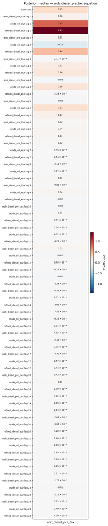

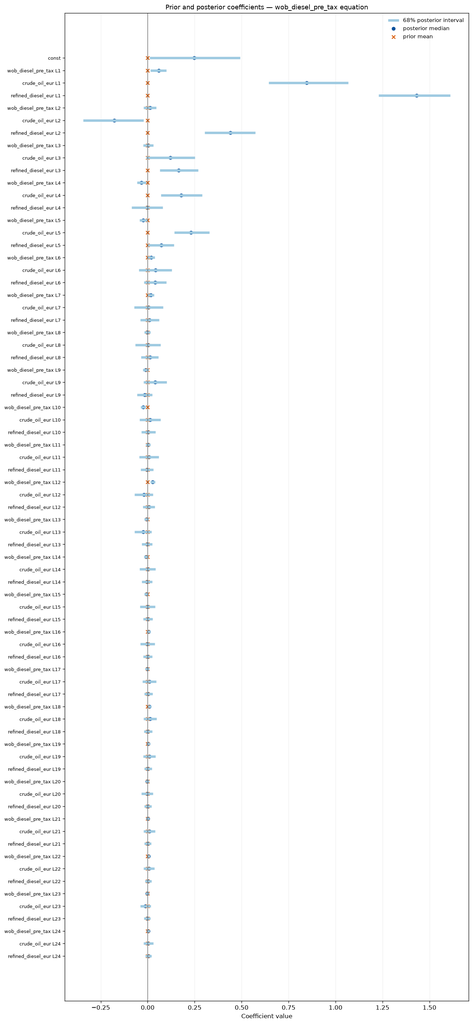

```
crude_oil_eur equation
```

Posterior coefficients — crude_oil_eur equation

| regressor | prior_mean | prior_sd | posterior_mean | posterior_median | posterior_sd | q05 | q16 | q84 | q95 | ESS |
| --- | --- | --- | --- | --- | --- | --- | --- | --- | --- | --- |
| const | 0.00 | 24.24 | 0.05 | 0.05 | 0.05 | -0.03 | 9.87 × 10⁻⁴ | 0.11 | 0.14 | 1537.97 |
| wob_diesel_pre_tax L1 | 0.00 | 0.01 | 0.03 | 0.03 | 7.86 × 10⁻³ | 0.01 | 0.02 | 0.03 | 0.04 | 1680.01 |
| crude_oil_eur L1 | 0.00 | 0.20 | 0.19 | 0.19 | 0.04 | 0.11 | 0.14 | 0.23 | 0.26 | 1209.57 |
| refined_diesel_eur L1 | 0.00 | 0.06 | -0.06 | -0.06 | 0.04 | -0.12 | -0.09 | -0.02 | 4.28 × 10⁻³ | 1424.94 |
| wob_diesel_pre_tax L2 | 0.00 | 7.38 × 10⁻³ | -2.43 × 10⁻³ | -2.48 × 10⁻³ | 5.21 × 10⁻³ | -0.01 | -7.57 × 10⁻³ | 2.81 × 10⁻³ | 6.07 × 10⁻³ | 2436.69 |
| crude_oil_eur L2 | 0.00 | 0.10 | -0.02 | -0.02 | 0.04 | -0.08 | -0.05 | 0.02 | 0.04 | 2316.83 |
| refined_diesel_eur L2 | 0.00 | 0.03 | -0.02 | -0.02 | 0.02 | -0.06 | -0.05 | -9.45 × 10⁻⁴ | 0.01 | 2496.29 |
| wob_diesel_pre_tax L3 | 0.00 | 4.92 × 10⁻³ | -1.22 × 10⁻³ | -1.23 × 10⁻³ | 3.98 × 10⁻³ | -7.73 × 10⁻³ | -5.25 × 10⁻³ | 2.84 × 10⁻³ | 5.24 × 10⁻³ | 2377.57 |
| crude_oil_eur L3 | 0.00 | 0.07 | -0.02 | -0.02 | 0.03 | -0.06 | -0.05 | 9.71 × 10⁻³ | 0.03 | 1772.79 |
| refined_diesel_eur L3 | 0.00 | 0.02 | -4.52 × 10⁻³ | -4.12 × 10⁻³ | 0.02 | -0.03 | -0.02 | 0.01 | 0.02 | 2289.92 |
| wob_diesel_pre_tax L4 | 0.00 | 3.69 × 10⁻³ | 4.32 × 10⁻³ | 4.30 × 10⁻³ | 3.17 × 10⁻³ | -8.13 × 10⁻⁴ | 1.14 × 10⁻³ | 7.51 × 10⁻³ | 9.53 × 10⁻³ | 2592.84 |
| crude_oil_eur L4 | 0.00 | 0.05 | -0.03 | -0.03 | 0.02 | -0.07 | -0.05 | -5.51 × 10⁻⁴ | 0.02 | 2149.95 |
| refined_diesel_eur L4 | 0.00 | 0.01 | 4.77 × 10⁻³ | 4.98 × 10⁻³ | 0.01 | -0.02 | -8.38 × 10⁻³ | 0.02 | 0.03 | 2667.97 |
| wob_diesel_pre_tax L5 | 0.00 | 2.95 × 10⁻³ | 1.52 × 10⁻³ | 1.52 × 10⁻³ | 2.55 × 10⁻³ | -2.64 × 10⁻³ | -9.65 × 10⁻⁴ | 4.00 × 10⁻³ | 5.77 × 10⁻³ | 2452.30 |
| crude_oil_eur L5 | 0.00 | 0.04 | 9.27 × 10⁻³ | 9.03 × 10⁻³ | 0.02 | -0.03 | -0.01 | 0.03 | 0.05 | 2664.65 |
| refined_diesel_eur L5 | 0.00 | 0.01 | 4.06 × 10⁻³ | 4.13 × 10⁻³ | 0.01 | -0.01 | -6.37 × 10⁻³ | 0.01 | 0.02 | 3000.00 |
| wob_diesel_pre_tax L6 | 0.00 | 2.46 × 10⁻³ | 1.79 × 10⁻³ | 1.80 × 10⁻³ | 2.23 × 10⁻³ | -1.92 × 10⁻³ | -4.69 × 10⁻⁴ | 4.04 × 10⁻³ | 5.49 × 10⁻³ | 2821.07 |
| crude_oil_eur L6 | 0.00 | 0.03 | -0.01 | -0.01 | 0.02 | -0.05 | -0.03 | 6.15 × 10⁻³ | 0.02 | 1852.53 |
| refined_diesel_eur L6 | 0.00 | 9.80 × 10⁻³ | 4.91 × 10⁻³ | 4.97 × 10⁻³ | 9.08 × 10⁻³ | -0.01 | -3.98 × 10⁻³ | 0.01 | 0.02 | 2974.81 |
| wob_diesel_pre_tax L7 | 0.00 | 2.11 × 10⁻³ | 8.68 × 10⁻⁴ | 9.31 × 10⁻⁴ | 1.93 × 10⁻³ | -2.38 × 10⁻³ | -1.09 × 10⁻³ | 2.79 × 10⁻³ | 4.00 × 10⁻³ | 2529.01 |
| crude_oil_eur L7 | 0.00 | 0.03 | -0.02 | -0.02 | 0.02 | -0.05 | -0.04 | -5.95 × 10⁻³ | 5.37 × 10⁻³ | 2089.31 |
| refined_diesel_eur L7 | 0.00 | 8.40 × 10⁻³ | 3.44 × 10⁻³ | 3.52 × 10⁻³ | 7.81 × 10⁻³ | -9.27 × 10⁻³ | -4.49 × 10⁻³ | 0.01 | 0.02 | 2820.94 |
| wob_diesel_pre_tax L8 | 0.00 | 1.84 × 10⁻³ | 1.06 × 10⁻³ | 1.06 × 10⁻³ | 1.72 × 10⁻³ | -1.75 × 10⁻³ | -6.87 × 10⁻⁴ | 2.73 × 10⁻³ | 3.94 × 10⁻³ | 3000.00 |
| crude_oil_eur L8 | 0.00 | 0.03 | 0.02 | 0.02 | 0.02 | -6.70 × 10⁻³ | 5.47 × 10⁻³ | 0.04 | 0.05 | 2561.90 |
| refined_diesel_eur L8 | 0.00 | 7.35 × 10⁻³ | 2.78 × 10⁻³ | 2.60 × 10⁻³ | 7.00 × 10⁻³ | -8.26 × 10⁻³ | -4.13 × 10⁻³ | 9.94 × 10⁻³ | 0.01 | 3000.00 |
| wob_diesel_pre_tax L9 | 0.00 | 1.64 × 10⁻³ | -3.76 × 10⁻⁴ | -3.58 × 10⁻⁴ | 1.54 × 10⁻³ | -2.86 × 10⁻³ | -1.93 × 10⁻³ | 1.15 × 10⁻³ | 2.18 × 10⁻³ | 2592.57 |
| crude_oil_eur L9 | 0.00 | 0.02 | -0.02 | -0.02 | 0.02 | -0.04 | -0.03 | -1.92 × 10⁻³ | 8.15 × 10⁻³ | 2622.80 |
| refined_diesel_eur L9 | 0.00 | 6.53 × 10⁻³ | -1.97 × 10⁻³ | -1.84 × 10⁻³ | 6.23 × 10⁻³ | -0.01 | -8.09 × 10⁻³ | 4.17 × 10⁻³ | 8.18 × 10⁻³ | 2920.10 |
| wob_diesel_pre_tax L10 | 0.00 | 1.48 × 10⁻³ | 1.00 × 10⁻⁴ | 1.13 × 10⁻⁴ | 1.40 × 10⁻³ | -2.27 × 10⁻³ | -1.28 × 10⁻³ | 1.47 × 10⁻³ | 2.42 × 10⁻³ | 2396.13 |
| crude_oil_eur L10 | 0.00 | 0.02 | -0.02 | -0.02 | 0.01 | -0.04 | -0.03 | -4.58 × 10⁻³ | 4.41 × 10⁻³ | 2197.18 |
| refined_diesel_eur L10 | 0.00 | 5.88 × 10⁻³ | 4.20 × 10⁻⁴ | 4.13 × 10⁻⁴ | 5.65 × 10⁻³ | -8.69 × 10⁻³ | -5.00 × 10⁻³ | 5.95 × 10⁻³ | 9.75 × 10⁻³ | 2787.09 |
| wob_diesel_pre_tax L11 | 0.00 | 1.34 × 10⁻³ | -1.67 × 10⁻⁴ | -1.64 × 10⁻⁴ | 1.27 × 10⁻³ | -2.29 × 10⁻³ | -1.41 × 10⁻³ | 1.09 × 10⁻³ | 1.95 × 10⁻³ | 2980.15 |
| crude_oil_eur L11 | 0.00 | 0.02 | -3.24 × 10⁻³ | -3.07 × 10⁻³ | 0.01 | -0.03 | -0.02 | 0.01 | 0.02 | 2503.95 |
| refined_diesel_eur L11 | 0.00 | 5.34 × 10⁻³ | 1.63 × 10⁻⁴ | 6.86 × 10⁻⁵ | 5.22 × 10⁻³ | -8.30 × 10⁻³ | -4.88 × 10⁻³ | 5.47 × 10⁻³ | 8.77 × 10⁻³ | 2859.24 |
| wob_diesel_pre_tax L12 | 0.00 | 1.23 × 10⁻³ | 1.47 × 10⁻⁵ | 2.90 × 10⁻⁵ | 1.19 × 10⁻³ | -1.99 × 10⁻³ | -1.16 × 10⁻³ | 1.21 × 10⁻³ | 1.95 × 10⁻³ | 3000.00 |
| crude_oil_eur L12 | 0.00 | 0.02 | -0.01 | -0.01 | 0.01 | -0.03 | -0.02 | 1.40 × 10⁻³ | 9.47 × 10⁻³ | 2523.90 |
| refined_diesel_eur L12 | 0.00 | 4.90 × 10⁻³ | -4.28 × 10⁻⁴ | -3.96 × 10⁻⁴ | 4.63 × 10⁻³ | -7.93 × 10⁻³ | -5.03 × 10⁻³ | 4.12 × 10⁻³ | 7.15 × 10⁻³ | 3000.00 |
| wob_diesel_pre_tax L13 | 0.00 | 1.14 × 10⁻³ | -2.49 × 10⁻⁴ | -2.48 × 10⁻⁴ | 1.10 × 10⁻³ | -2.06 × 10⁻³ | -1.38 × 10⁻³ | 8.52 × 10⁻⁴ | 1.52 × 10⁻³ | 2830.61 |
| crude_oil_eur L13 | 0.00 | 0.02 | 6.22 × 10⁻³ | 6.09 × 10⁻³ | 0.01 | -0.01 | -6.00 × 10⁻³ | 0.02 | 0.03 | 2306.29 |
| refined_diesel_eur L13 | 0.00 | 4.52 × 10⁻³ | -1.05 × 10⁻³ | -1.13 × 10⁻³ | 4.38 × 10⁻³ | -8.03 × 10⁻³ | -5.45 × 10⁻³ | 3.45 × 10⁻³ | 6.28 × 10⁻³ | 3000.00 |
| wob_diesel_pre_tax L14 | 0.00 | 1.05 × 10⁻³ | 4.02 × 10⁻⁵ | 3.88 × 10⁻⁵ | 1.01 × 10⁻³ | -1.61 × 10⁻³ | -9.65 × 10⁻⁴ | 1.02 × 10⁻³ | 1.75 × 10⁻³ | 2817.41 |
| crude_oil_eur L14 | 0.00 | 0.01 | 9.30 × 10⁻³ | 9.46 × 10⁻³ | 0.01 | -9.28 × 10⁻³ | -1.73 × 10⁻³ | 0.02 | 0.03 | 2482.62 |
| refined_diesel_eur L14 | 0.00 | 4.20 × 10⁻³ | 8.24 × 10⁻⁴ | 7.90 × 10⁻⁴ | 4.13 × 10⁻³ | -5.84 × 10⁻³ | -3.16 × 10⁻³ | 4.94 × 10⁻³ | 7.59 × 10⁻³ | 2828.95 |
| wob_diesel_pre_tax L15 | 0.00 | 9.84 × 10⁻⁴ | -1.17 × 10⁻⁴ | -9.97 × 10⁻⁵ | 9.46 × 10⁻⁴ | -1.63 × 10⁻³ | -1.10 × 10⁻³ | 8.12 × 10⁻⁴ | 1.45 × 10⁻³ | 2875.32 |
| crude_oil_eur L15 | 0.00 | 0.01 | -9.60 × 10⁻³ | -9.62 × 10⁻³ | 0.01 | -0.03 | -0.02 | 9.78 × 10⁻⁴ | 7.57 × 10⁻³ | 2724.74 |
| refined_diesel_eur L15 | 0.00 | 3.92 × 10⁻³ | -1.44 × 10⁻⁴ | -1.71 × 10⁻⁴ | 3.93 × 10⁻³ | -6.45 × 10⁻³ | -4.06 × 10⁻³ | 3.78 × 10⁻³ | 6.40 × 10⁻³ | 3000.00 |
| wob_diesel_pre_tax L16 | 0.00 | 9.22 × 10⁻⁴ | -1.88 × 10⁻⁴ | -2.08 × 10⁻⁴ | 8.88 × 10⁻⁴ | -1.64 × 10⁻³ | -1.08 × 10⁻³ | 7.39 × 10⁻⁴ | 1.26 × 10⁻³ | 3000.00 |
| crude_oil_eur L16 | 0.00 | 0.01 | -3.05 × 10⁻³ | -2.95 × 10⁻³ | 0.01 | -0.02 | -0.01 | 6.68 × 10⁻³ | 0.01 | 2747.31 |
| refined_diesel_eur L16 | 0.00 | 3.67 × 10⁻³ | -2.27 × 10⁻⁴ | -2.63 × 10⁻⁴ | 3.60 × 10⁻³ | -5.90 × 10⁻³ | -3.78 × 10⁻³ | 3.33 × 10⁻³ | 5.74 × 10⁻³ | 2812.39 |
| wob_diesel_pre_tax L17 | 0.00 | 8.68 × 10⁻⁴ | -7.84 × 10⁻⁵ | -7.32 × 10⁻⁵ | 8.57 × 10⁻⁴ | -1.50 × 10⁻³ | -9.51 × 10⁻⁴ | 7.78 × 10⁻⁴ | 1.30 × 10⁻³ | 3000.00 |
| crude_oil_eur L17 | 0.00 | 0.01 | 5.35 × 10⁻³ | 5.34 × 10⁻³ | 9.82 × 10⁻³ | -0.01 | -4.49 × 10⁻³ | 0.02 | 0.02 | 2253.09 |
| refined_diesel_eur L17 | 0.00 | 3.46 × 10⁻³ | -1.69 × 10⁻⁴ | -1.19 × 10⁻⁴ | 3.40 × 10⁻³ | -5.89 × 10⁻³ | -3.50 × 10⁻³ | 3.18 × 10⁻³ | 5.44 × 10⁻³ | 2831.74 |
| wob_diesel_pre_tax L18 | 0.00 | 8.20 × 10⁻⁴ | -1.28 × 10⁻⁴ | -1.28 × 10⁻⁴ | 7.92 × 10⁻⁴ | -1.41 × 10⁻³ | -9.42 × 10⁻⁴ | 6.73 × 10⁻⁴ | 1.20 × 10⁻³ | 2959.41 |
| crude_oil_eur L18 | 0.00 | 0.01 | -6.72 × 10⁻³ | -6.95 × 10⁻³ | 9.38 × 10⁻³ | -0.02 | -0.02 | 2.64 × 10⁻³ | 8.95 × 10⁻³ | 2824.08 |
| refined_diesel_eur L18 | 0.00 | 3.27 × 10⁻³ | -3.50 × 10⁻⁴ | -4.24 × 10⁻⁴ | 3.19 × 10⁻³ | -5.49 × 10⁻³ | -3.43 × 10⁻³ | 2.85 × 10⁻³ | 5.05 × 10⁻³ | 3000.00 |
| wob_diesel_pre_tax L19 | 0.00 | 7.77 × 10⁻⁴ | -2.16 × 10⁻⁴ | -2.29 × 10⁻⁴ | 7.65 × 10⁻⁴ | -1.46 × 10⁻³ | -9.63 × 10⁻⁴ | 5.32 × 10⁻⁴ | 1.10 × 10⁻³ | 3000.00 |
| crude_oil_eur L19 | 0.00 | 0.01 | -7.81 × 10⁻³ | -7.83 × 10⁻³ | 8.62 × 10⁻³ | -0.02 | -0.02 | 8.01 × 10⁻⁴ | 6.15 × 10⁻³ | 3000.00 |
| refined_diesel_eur L19 | 0.00 | 3.09 × 10⁻³ | -3.77 × 10⁻⁴ | -3.91 × 10⁻⁴ | 2.98 × 10⁻³ | -5.24 × 10⁻³ | -3.37 × 10⁻³ | 2.60 × 10⁻³ | 4.48 × 10⁻³ | 2940.34 |
| wob_diesel_pre_tax L20 | 0.00 | 7.38 × 10⁻⁴ | -2.36 × 10⁻⁴ | -2.43 × 10⁻⁴ | 7.23 × 10⁻⁴ | -1.45 × 10⁻³ | -9.51 × 10⁻⁴ | 4.85 × 10⁻⁴ | 9.34 × 10⁻⁴ | 3000.00 |
| crude_oil_eur L20 | 0.00 | 0.01 | -3.28 × 10⁻³ | -3.39 × 10⁻³ | 8.82 × 10⁻³ | -0.02 | -0.01 | 5.45 × 10⁻³ | 0.01 | 2273.89 |
| refined_diesel_eur L20 | 0.00 | 2.94 × 10⁻³ | -5.70 × 10⁻⁴ | -6.06 × 10⁻⁴ | 2.87 × 10⁻³ | -5.25 × 10⁻³ | -3.44 × 10⁻³ | 2.34 × 10⁻³ | 4.08 × 10⁻³ | 2887.43 |
| wob_diesel_pre_tax L21 | 0.00 | 7.03 × 10⁻⁴ | -5.00 × 10⁻⁵ | -5.06 × 10⁻⁵ | 6.88 × 10⁻⁴ | -1.19 × 10⁻³ | -7.28 × 10⁻⁴ | 6.23 × 10⁻⁴ | 1.09 × 10⁻³ | 3000.00 |
| crude_oil_eur L21 | 0.00 | 9.52 × 10⁻³ | -1.88 × 10⁻³ | -2.01 × 10⁻³ | 8.26 × 10⁻³ | -0.02 | -0.01 | 6.59 × 10⁻³ | 0.01 | 2837.97 |
| refined_diesel_eur L21 | 0.00 | 2.80 × 10⁻³ | -7.53 × 10⁻⁴ | -7.87 × 10⁻⁴ | 2.77 × 10⁻³ | -5.31 × 10⁻³ | -3.46 × 10⁻³ | 2.03 × 10⁻³ | 4.01 × 10⁻³ | 3000.00 |
| wob_diesel_pre_tax L22 | 0.00 | 6.71 × 10⁻⁴ | -1.41 × 10⁻⁴ | -1.46 × 10⁻⁴ | 6.60 × 10⁻⁴ | -1.22 × 10⁻³ | -8.05 × 10⁻⁴ | 5.13 × 10⁻⁴ | 9.36 × 10⁻⁴ | 2757.87 |
| crude_oil_eur L22 | 0.00 | 9.09 × 10⁻³ | -3.60 × 10⁻³ | -3.51 × 10⁻³ | 7.94 × 10⁻³ | -0.02 | -0.01 | 4.28 × 10⁻³ | 9.69 × 10⁻³ | 2563.87 |
| refined_diesel_eur L22 | 0.00 | 2.67 × 10⁻³ | -4.36 × 10⁻⁴ | -4.92 × 10⁻⁴ | 2.59 × 10⁻³ | -4.57 × 10⁻³ | -2.99 × 10⁻³ | 2.14 × 10⁻³ | 3.78 × 10⁻³ | 2835.33 |
| wob_diesel_pre_tax L23 | 0.00 | 6.42 × 10⁻⁴ | -1.40 × 10⁻⁴ | -1.28 × 10⁻⁴ | 6.35 × 10⁻⁴ | -1.22 × 10⁻³ | -7.77 × 10⁻⁴ | 4.84 × 10⁻⁴ | 9.05 × 10⁻⁴ | 2926.86 |
| crude_oil_eur L23 | 0.00 | 8.70 × 10⁻³ | 2.73 × 10⁻³ | 2.79 × 10⁻³ | 7.52 × 10⁻³ | -0.01 | -4.90 × 10⁻³ | 0.01 | 0.01 | 2050.67 |
| refined_diesel_eur L23 | 0.00 | 2.56 × 10⁻³ | 1.92 × 10⁻⁵ | 1.46 × 10⁻⁵ | 2.48 × 10⁻³ | -4.03 × 10⁻³ | -2.49 × 10⁻³ | 2.51 × 10⁻³ | 4.14 × 10⁻³ | 2997.12 |
| wob_diesel_pre_tax L24 | 0.00 | 6.15 × 10⁻⁴ | -1.72 × 10⁻⁴ | -1.77 × 10⁻⁴ | 5.95 × 10⁻⁴ | -1.14 × 10⁻³ | -7.52 × 10⁻⁴ | 4.10 × 10⁻⁴ | 8.42 × 10⁻⁴ | 3000.00 |
| crude_oil_eur L24 | 0.00 | 8.33 × 10⁻³ | -4.39 × 10⁻³ | -4.45 × 10⁻³ | 7.47 × 10⁻³ | -0.02 | -0.01 | 2.96 × 10⁻³ | 8.03 × 10⁻³ | 2834.43 |
| refined_diesel_eur L24 | 0.00 | 2.45 × 10⁻³ | -3.44 × 10⁻⁴ | -3.55 × 10⁻⁴ | 2.42 × 10⁻³ | -4.42 × 10⁻³ | -2.72 × 10⁻³ | 2.08 × 10⁻³ | 3.67 × 10⁻³ | 3000.00 |

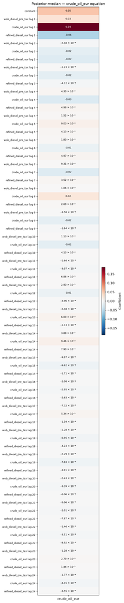

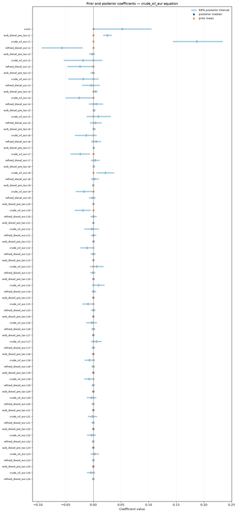

```
refined_diesel_eur equation
```

Posterior coefficients — refined_diesel_eur equation

| regressor | prior_mean | prior_sd | posterior_mean | posterior_median | posterior_sd | q05 | q16 | q84 | q95 | ESS |
| --- | --- | --- | --- | --- | --- | --- | --- | --- | --- | --- |
| const | 0.00 | 41.24 | 0.05 | 0.05 | 0.06 | -0.05 | -8.38 × 10⁻³ | 0.11 | 0.15 | 1322.90 |
| wob_diesel_pre_tax L1 | 0.00 | 0.03 | 0.05 | 0.05 | 0.01 | 0.03 | 0.04 | 0.06 | 0.07 | 1503.60 |
| crude_oil_eur L1 | 0.00 | 0.17 | 0.23 | 0.23 | 0.05 | 0.14 | 0.17 | 0.28 | 0.31 | 524.06 |
| refined_diesel_eur L1 | 0.00 | 0.20 | -0.11 | -0.11 | 0.05 | -0.19 | -0.16 | -0.07 | -0.03 | 1336.45 |
| wob_diesel_pre_tax L2 | 0.00 | 0.01 | 0.01 | 0.01 | 7.17 × 10⁻³ | 1.16 × 10⁻³ | 5.71 × 10⁻³ | 0.02 | 0.02 | 2351.90 |
| crude_oil_eur L2 | 0.00 | 0.09 | -0.04 | -0.04 | 0.04 | -0.11 | -0.08 | -1.39 × 10⁻³ | 0.02 | 2386.25 |
| refined_diesel_eur L2 | 0.00 | 0.10 | -0.12 | -0.12 | 0.04 | -0.17 | -0.15 | -0.08 | -0.05 | 1983.97 |
| wob_diesel_pre_tax L3 | 0.00 | 8.37 × 10⁻³ | 3.87 × 10⁻³ | 3.78 × 10⁻³ | 5.68 × 10⁻³ | -5.35 × 10⁻³ | -1.82 × 10⁻³ | 9.51 × 10⁻³ | 0.01 | 2395.42 |
| crude_oil_eur L3 | 0.00 | 0.06 | 0.03 | 0.03 | 0.03 | -0.02 | 1.78 × 10⁻³ | 0.07 | 0.09 | 1675.96 |
| refined_diesel_eur L3 | 0.00 | 0.07 | -0.09 | -0.09 | 0.03 | -0.14 | -0.12 | -0.06 | -0.05 | 1664.86 |
| wob_diesel_pre_tax L4 | 0.00 | 6.28 × 10⁻³ | -4.75 × 10⁻³ | -4.90 × 10⁻³ | 4.61 × 10⁻³ | -0.01 | -9.23 × 10⁻³ | -2.10 × 10⁻⁴ | 2.95 × 10⁻³ | 1807.76 |
| crude_oil_eur L4 | 0.00 | 0.04 | -0.01 | -0.01 | 0.03 | -0.06 | -0.04 | 0.02 | 0.03 | 1938.35 |
| refined_diesel_eur L4 | 0.00 | 0.05 | -0.03 | -0.03 | 0.03 | -0.07 | -0.05 | -1.89 × 10⁻⁴ | 0.02 | 2249.94 |
| wob_diesel_pre_tax L5 | 0.00 | 5.02 × 10⁻³ | 1.79 × 10⁻³ | 1.75 × 10⁻³ | 3.94 × 10⁻³ | -4.70 × 10⁻³ | -2.16 × 10⁻³ | 5.66 × 10⁻³ | 8.35 × 10⁻³ | 2869.16 |
| crude_oil_eur L5 | 0.00 | 0.03 | 8.50 × 10⁻³ | 8.34 × 10⁻³ | 0.02 | -0.03 | -0.01 | 0.03 | 0.05 | 2522.05 |
| refined_diesel_eur L5 | 0.00 | 0.04 | -2.31 × 10⁻⁴ | -2.68 × 10⁻⁴ | 0.02 | -0.04 | -0.02 | 0.02 | 0.04 | 2203.91 |
| wob_diesel_pre_tax L6 | 0.00 | 4.18 × 10⁻³ | -1.89 × 10⁻³ | -1.86 × 10⁻³ | 3.43 × 10⁻³ | -7.52 × 10⁻³ | -5.31 × 10⁻³ | 1.52 × 10⁻³ | 3.63 × 10⁻³ | 2744.88 |
| crude_oil_eur L6 | 0.00 | 0.03 | 0.03 | 0.03 | 0.02 | -4.71 × 10⁻³ | 8.82 × 10⁻³ | 0.05 | 0.06 | 2093.35 |
| refined_diesel_eur L6 | 0.00 | 0.03 | -0.02 | -0.02 | 0.02 | -0.05 | -0.04 | -2.01 × 10⁻³ | 0.01 | 2048.00 |
| wob_diesel_pre_tax L7 | 0.00 | 3.59 × 10⁻³ | -3.89 × 10⁻⁴ | -3.15 × 10⁻⁴ | 3.02 × 10⁻³ | -5.45 × 10⁻³ | -3.44 × 10⁻³ | 2.59 × 10⁻³ | 4.59 × 10⁻³ | 2407.60 |
| crude_oil_eur L7 | 0.00 | 0.02 | 0.02 | 0.02 | 0.02 | -8.34 × 10⁻³ | 4.43 × 10⁻³ | 0.04 | 0.05 | 2460.99 |
| refined_diesel_eur L7 | 0.00 | 0.03 | -0.03 | -0.03 | 0.02 | -0.06 | -0.04 | -6.92 × 10⁻³ | 4.55 × 10⁻³ | 2613.87 |
| wob_diesel_pre_tax L8 | 0.00 | 3.14 × 10⁻³ | -5.87 × 10⁻⁴ | -6.39 × 10⁻⁴ | 2.67 × 10⁻³ | -5.00 × 10⁻³ | -3.24 × 10⁻³ | 2.08 × 10⁻³ | 3.82 × 10⁻³ | 2246.03 |
| crude_oil_eur L8 | 0.00 | 0.02 | 5.10 × 10⁻³ | 4.90 × 10⁻³ | 0.02 | -0.02 | -0.01 | 0.02 | 0.03 | 2621.07 |
| refined_diesel_eur L8 | 0.00 | 0.03 | -8.88 × 10⁻⁴ | -7.22 × 10⁻⁴ | 0.02 | -0.03 | -0.02 | 0.02 | 0.03 | 2213.24 |
| wob_diesel_pre_tax L9 | 0.00 | 2.79 × 10⁻³ | -3.54 × 10⁻⁴ | -3.38 × 10⁻⁴ | 2.44 × 10⁻³ | -4.41 × 10⁻³ | -2.76 × 10⁻³ | 2.04 × 10⁻³ | 3.70 × 10⁻³ | 2951.66 |
| crude_oil_eur L9 | 0.00 | 0.02 | -7.62 × 10⁻³ | -7.52 × 10⁻³ | 0.01 | -0.03 | -0.02 | 6.39 × 10⁻³ | 0.02 | 2794.38 |
| refined_diesel_eur L9 | 0.00 | 0.02 | 6.47 × 10⁻³ | 6.31 × 10⁻³ | 0.02 | -0.02 | -8.87 × 10⁻³ | 0.02 | 0.03 | 2722.83 |
| wob_diesel_pre_tax L10 | 0.00 | 2.51 × 10⁻³ | 6.12 × 10⁻⁵ | 8.64 × 10⁻⁵ | 2.27 × 10⁻³ | -3.64 × 10⁻³ | -2.17 × 10⁻³ | 2.31 × 10⁻³ | 3.79 × 10⁻³ | 2596.85 |
| crude_oil_eur L10 | 0.00 | 0.02 | 3.79 × 10⁻⁴ | 3.97 × 10⁻⁴ | 0.01 | -0.02 | -0.01 | 0.01 | 0.02 | 2283.35 |
| refined_diesel_eur L10 | 0.00 | 0.02 | -6.55 × 10⁻³ | -6.82 × 10⁻³ | 0.01 | -0.03 | -0.02 | 7.43 × 10⁻³ | 0.02 | 2580.41 |
| wob_diesel_pre_tax L11 | 0.00 | 2.28 × 10⁻³ | 5.97 × 10⁻⁵ | 5.68 × 10⁻⁵ | 2.03 × 10⁻³ | -3.30 × 10⁻³ | -2.00 × 10⁻³ | 2.10 × 10⁻³ | 3.31 × 10⁻³ | 2863.53 |
| crude_oil_eur L11 | 0.00 | 0.02 | -1.41 × 10⁻³ | -1.21 × 10⁻³ | 0.01 | -0.02 | -0.01 | 0.01 | 0.02 | 2847.35 |
| refined_diesel_eur L11 | 0.00 | 0.02 | -5.09 × 10⁻³ | -4.84 × 10⁻³ | 0.01 | -0.03 | -0.02 | 7.88 × 10⁻³ | 0.02 | 2306.10 |
| wob_diesel_pre_tax L12 | 0.00 | 2.09 × 10⁻³ | -1.45 × 10⁻³ | -1.46 × 10⁻³ | 1.87 × 10⁻³ | -4.47 × 10⁻³ | -3.31 × 10⁻³ | 4.37 × 10⁻⁴ | 1.61 × 10⁻³ | 2948.16 |
| crude_oil_eur L12 | 0.00 | 0.01 | 5.31 × 10⁻³ | 5.00 × 10⁻³ | 0.01 | -0.01 | -6.90 × 10⁻³ | 0.02 | 0.03 | 2908.09 |
| refined_diesel_eur L12 | 0.00 | 0.02 | -0.01 | -0.01 | 0.01 | -0.03 | -0.02 | 1.79 × 10⁻³ | 0.01 | 2867.02 |
| wob_diesel_pre_tax L13 | 0.00 | 1.93 × 10⁻³ | 7.35 × 10⁻⁴ | 7.10 × 10⁻⁴ | 1.81 × 10⁻³ | -2.21 × 10⁻³ | -1.04 × 10⁻³ | 2.58 × 10⁻³ | 3.72 × 10⁻³ | 2778.72 |
| crude_oil_eur L13 | 0.00 | 0.01 | 2.38 × 10⁻³ | 2.31 × 10⁻³ | 0.01 | -0.02 | -8.70 × 10⁻³ | 0.01 | 0.02 | 2715.51 |
| refined_diesel_eur L13 | 0.00 | 0.02 | 3.14 × 10⁻³ | 3.05 × 10⁻³ | 0.01 | -0.02 | -8.19 × 10⁻³ | 0.01 | 0.02 | 2410.34 |
| wob_diesel_pre_tax L14 | 0.00 | 1.79 × 10⁻³ | 5.57 × 10⁻⁴ | 6.03 × 10⁻⁴ | 1.66 × 10⁻³ | -2.18 × 10⁻³ | -1.20 × 10⁻³ | 2.22 × 10⁻³ | 3.17 × 10⁻³ | 3000.00 |
| crude_oil_eur L14 | 0.00 | 0.01 | -7.07 × 10⁻³ | -7.23 × 10⁻³ | 0.01 | -0.02 | -0.02 | 3.58 × 10⁻³ | 0.01 | 2816.07 |
| refined_diesel_eur L14 | 0.00 | 0.01 | -5.74 × 10⁻³ | -5.88 × 10⁻³ | 0.01 | -0.02 | -0.02 | 5.23 × 10⁻³ | 0.01 | 2512.61 |
| wob_diesel_pre_tax L15 | 0.00 | 1.67 × 10⁻³ | 7.72 × 10⁻⁵ | 1.04 × 10⁻⁴ | 1.56 × 10⁻³ | -2.51 × 10⁻³ | -1.50 × 10⁻³ | 1.61 × 10⁻³ | 2.62 × 10⁻³ | 2911.58 |
| crude_oil_eur L15 | 0.00 | 0.01 | 3.19 × 10⁻³ | 3.20 × 10⁻³ | 9.98 × 10⁻³ | -0.01 | -6.72 × 10⁻³ | 0.01 | 0.02 | 2716.05 |
| refined_diesel_eur L15 | 0.00 | 0.01 | -2.99 × 10⁻³ | -2.89 × 10⁻³ | 0.01 | -0.02 | -0.01 | 7.33 × 10⁻³ | 0.01 | 2497.64 |
| wob_diesel_pre_tax L16 | 0.00 | 1.57 × 10⁻³ | 2.57 × 10⁻⁴ | 2.39 × 10⁻⁴ | 1.46 × 10⁻³ | -2.17 × 10⁻³ | -1.16 × 10⁻³ | 1.71 × 10⁻³ | 2.61 × 10⁻³ | 2638.91 |
| crude_oil_eur L16 | 0.00 | 0.01 | 3.54 × 10⁻⁴ | 3.56 × 10⁻⁴ | 9.35 × 10⁻³ | -0.02 | -8.83 × 10⁻³ | 9.51 × 10⁻³ | 0.02 | 2428.93 |
| refined_diesel_eur L16 | 0.00 | 0.01 | -1.32 × 10⁻³ | -1.18 × 10⁻³ | 9.95 × 10⁻³ | -0.02 | -0.01 | 8.82 × 10⁻³ | 0.01 | 2432.67 |
| wob_diesel_pre_tax L17 | 0.00 | 1.48 × 10⁻³ | 5.53 × 10⁻⁴ | 5.73 × 10⁻⁴ | 1.40 × 10⁻³ | -1.86 × 10⁻³ | -8.45 × 10⁻⁴ | 1.94 × 10⁻³ | 2.86 × 10⁻³ | 2468.98 |
| crude_oil_eur L17 | 0.00 | 0.01 | -2.66 × 10⁻³ | -2.86 × 10⁻³ | 8.84 × 10⁻³ | -0.02 | -0.01 | 6.19 × 10⁻³ | 0.01 | 2708.51 |
| refined_diesel_eur L17 | 0.00 | 0.01 | 4.08 × 10⁻³ | 3.98 × 10⁻³ | 9.58 × 10⁻³ | -0.01 | -5.25 × 10⁻³ | 0.01 | 0.02 | 2760.39 |
| wob_diesel_pre_tax L18 | 0.00 | 1.39 × 10⁻³ | -9.11 × 10⁻⁵ | -9.99 × 10⁻⁵ | 1.30 × 10⁻³ | -2.21 × 10⁻³ | -1.40 × 10⁻³ | 1.22 × 10⁻³ | 2.05 × 10⁻³ | 3000.00 |
| crude_oil_eur L18 | 0.00 | 9.45 × 10⁻³ | 8.92 × 10⁻⁴ | 1.03 × 10⁻³ | 8.40 × 10⁻³ | -0.01 | -7.56 × 10⁻³ | 9.13 × 10⁻³ | 0.01 | 2752.37 |
| refined_diesel_eur L18 | 0.00 | 0.01 | 2.33 × 10⁻³ | 2.10 × 10⁻³ | 9.19 × 10⁻³ | -0.01 | -6.88 × 10⁻³ | 0.01 | 0.02 | 2571.44 |
| wob_diesel_pre_tax L19 | 0.00 | 1.32 × 10⁻³ | 1.11 × 10⁻⁴ | 9.70 × 10⁻⁵ | 1.23 × 10⁻³ | -1.93 × 10⁻³ | -1.13 × 10⁻³ | 1.35 × 10⁻³ | 2.13 × 10⁻³ | 2958.05 |
| crude_oil_eur L19 | 0.00 | 8.95 × 10⁻³ | -1.28 × 10⁻³ | -1.09 × 10⁻³ | 8.09 × 10⁻³ | -0.01 | -9.25 × 10⁻³ | 6.93 × 10⁻³ | 0.01 | 2855.57 |
| refined_diesel_eur L19 | 0.00 | 0.01 | -7.90 × 10⁻⁴ | -1.03 × 10⁻³ | 8.74 × 10⁻³ | -0.02 | -9.44 × 10⁻³ | 7.65 × 10⁻³ | 0.01 | 2676.96 |
| wob_diesel_pre_tax L20 | 0.00 | 1.26 × 10⁻³ | 6.79 × 10⁻⁴ | 6.98 × 10⁻⁴ | 1.20 × 10⁻³ | -1.22 × 10⁻³ | -5.13 × 10⁻⁴ | 1.87 × 10⁻³ | 2.62 × 10⁻³ | 2630.55 |
| crude_oil_eur L20 | 0.00 | 8.51 × 10⁻³ | 3.11 × 10⁻³ | 3.14 × 10⁻³ | 7.53 × 10⁻³ | -9.48 × 10⁻³ | -4.22 × 10⁻³ | 0.01 | 0.02 | 2850.42 |
| refined_diesel_eur L20 | 0.00 | 0.01 | 5.65 × 10⁻³ | 5.64 × 10⁻³ | 8.26 × 10⁻³ | -8.01 × 10⁻³ | -2.59 × 10⁻³ | 0.01 | 0.02 | 2701.60 |
| wob_diesel_pre_tax L21 | 0.00 | 1.20 × 10⁻³ | -1.70 × 10⁻⁴ | -1.64 × 10⁻⁴ | 1.11 × 10⁻³ | -2.04 × 10⁻³ | -1.30 × 10⁻³ | 9.40 × 10⁻⁴ | 1.66 × 10⁻³ | 2966.78 |
| crude_oil_eur L21 | 0.00 | 8.10 × 10⁻³ | -2.71 × 10⁻³ | -2.86 × 10⁻³ | 7.25 × 10⁻³ | -0.01 | -9.93 × 10⁻³ | 4.51 × 10⁻³ | 9.14 × 10⁻³ | 2325.06 |
| refined_diesel_eur L21 | 0.00 | 9.52 × 10⁻³ | 3.15 × 10⁻³ | 3.17 × 10⁻³ | 7.90 × 10⁻³ | -9.94 × 10⁻³ | -4.91 × 10⁻³ | 0.01 | 0.02 | 2302.99 |
| wob_diesel_pre_tax L22 | 0.00 | 1.14 × 10⁻³ | 9.38 × 10⁻⁶ | 2.40 × 10⁻⁵ | 1.08 × 10⁻³ | -1.77 × 10⁻³ | -1.11 × 10⁻³ | 1.08 × 10⁻³ | 1.78 × 10⁻³ | 2840.01 |
| crude_oil_eur L22 | 0.00 | 7.73 × 10⁻³ | 1.37 × 10⁻⁵ | 1.40 × 10⁻⁴ | 7.04 × 10⁻³ | -0.01 | -7.16 × 10⁻³ | 7.02 × 10⁻³ | 0.01 | 2898.12 |
| refined_diesel_eur L22 | 0.00 | 9.09 × 10⁻³ | 1.66 × 10⁻³ | 1.65 × 10⁻³ | 7.46 × 10⁻³ | -0.01 | -5.56 × 10⁻³ | 8.85 × 10⁻³ | 0.01 | 2774.34 |
| wob_diesel_pre_tax L23 | 0.00 | 1.09 × 10⁻³ | 3.94 × 10⁻⁴ | 3.88 × 10⁻⁴ | 1.07 × 10⁻³ | -1.32 × 10⁻³ | -6.77 × 10⁻⁴ | 1.46 × 10⁻³ | 2.13 × 10⁻³ | 2980.27 |
| crude_oil_eur L23 | 0.00 | 7.40 × 10⁻³ | 1.02 × 10⁻³ | 1.13 × 10⁻³ | 6.65 × 10⁻³ | -9.70 × 10⁻³ | -5.64 × 10⁻³ | 7.81 × 10⁻³ | 0.01 | 2789.52 |
| refined_diesel_eur L23 | 0.00 | 8.70 × 10⁻³ | -2.38 × 10⁻³ | -2.45 × 10⁻³ | 7.29 × 10⁻³ | -0.01 | -9.43 × 10⁻³ | 5.11 × 10⁻³ | 9.88 × 10⁻³ | 2636.84 |
| wob_diesel_pre_tax L24 | 0.00 | 1.05 × 10⁻³ | 3.39 × 10⁻⁴ | 3.29 × 10⁻⁴ | 9.91 × 10⁻⁴ | -1.31 × 10⁻³ | -6.62 × 10⁻⁴ | 1.38 × 10⁻³ | 1.97 × 10⁻³ | 2696.56 |
| crude_oil_eur L24 | 0.00 | 7.09 × 10⁻³ | 3.40 × 10⁻³ | 3.15 × 10⁻³ | 6.43 × 10⁻³ | -6.79 × 10⁻³ | -2.97 × 10⁻³ | 9.81 × 10⁻³ | 0.01 | 2893.18 |
| refined_diesel_eur L24 | 0.00 | 8.33 × 10⁻³ | 1.25 × 10⁻³ | 1.16 × 10⁻³ | 7.28 × 10⁻³ | -0.01 | -5.91 × 10⁻³ | 8.44 × 10⁻³ | 0.01 | 2399.81 |

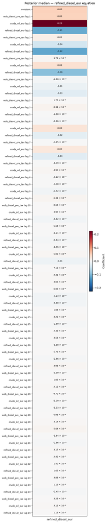

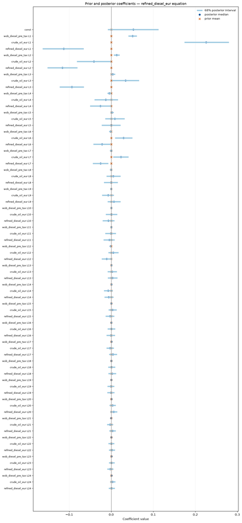

```python
coefficient_tables = coefficient_posterior_tables(result)
for equation in VARIABLES:
    print()
    print(f"{equation} equation")
    display(style_numeric_table(
        coefficient_tables[equation],
        caption=f"Posterior coefficients — {equation} equation",
    ))
    plot_coefficient_heatmap(result, equation=equation)
    plot_shrinkage_comparison(result, equations=[equation])
    plt.show()
```

MCMC diagnostics

|  | posterior_mean | posterior_sd | ESS | MCSE_mean | MCSE_over_sd |
| --- | --- | --- | --- | --- | --- |
| log likelihood | -7252.14 | 19.31 | 142.15 | 1.62 | 0.08 |
| spectral radius | 0.88 | 8.64 × 10⁻³ | 3000.00 | 1.58 × 10⁻⁴ | 0.02 |
| A[crude_oil_eur,wob_diesel_pre_tax] | -0.16 | 4.98 × 10⁻³ | 419.10 | 2.43 × 10⁻⁴ | 0.05 |
| phi[wob_diesel_pre_tax] | 0.03 | 8.21 × 10⁻³ | 9.70 | 2.64 × 10⁻³ | 0.32 |
| p_outlier[wob_diesel_pre_tax] | 0.01 | 4.82 × 10⁻³ | 18.63 | 1.12 × 10⁻³ | 0.23 |
| own L1[wob_diesel_pre_tax] | 0.06 | 0.04 | 1380.01 | 1.16 × 10⁻³ | 0.03 |
| phi[crude_oil_eur] | 0.03 | 7.46 × 10⁻³ | 51.03 | 1.04 × 10⁻³ | 0.14 |
| p_outlier[crude_oil_eur] | 6.79 × 10⁻³ | 3.06 × 10⁻³ | 867.36 | 1.04 × 10⁻⁴ | 0.03 |
| own L1[crude_oil_eur] | 0.19 | 0.04 | 1209.57 | 1.29 × 10⁻³ | 0.03 |
| phi[refined_diesel_eur] | 0.04 | 0.01 | 48.58 | 1.67 × 10⁻³ | 0.14 |
| p_outlier[refined_diesel_eur] | 5.27 × 10⁻³ | 2.87 × 10⁻³ | 315.35 | 1.62 × 10⁻⁴ | 0.06 |
| own L1[refined_diesel_eur] | -0.11 | 0.05 | 1336.45 | 1.34 × 10⁻³ | 0.03 |

VAR stability diagnostics

|  | value |
| --- | --- |
| retained_draws | 3000.00 |
| median_spectral_radius | 0.88 |
| q95_spectral_radius | 0.89 |
| maximum_spectral_radius | 0.91 |
| retained_unstable_share | 0.00 |
| B_total_proposals | 6000.00 |
| B_unstable_proposals | 0.00 |
| B_instability_rejection_rate | 0.00 |

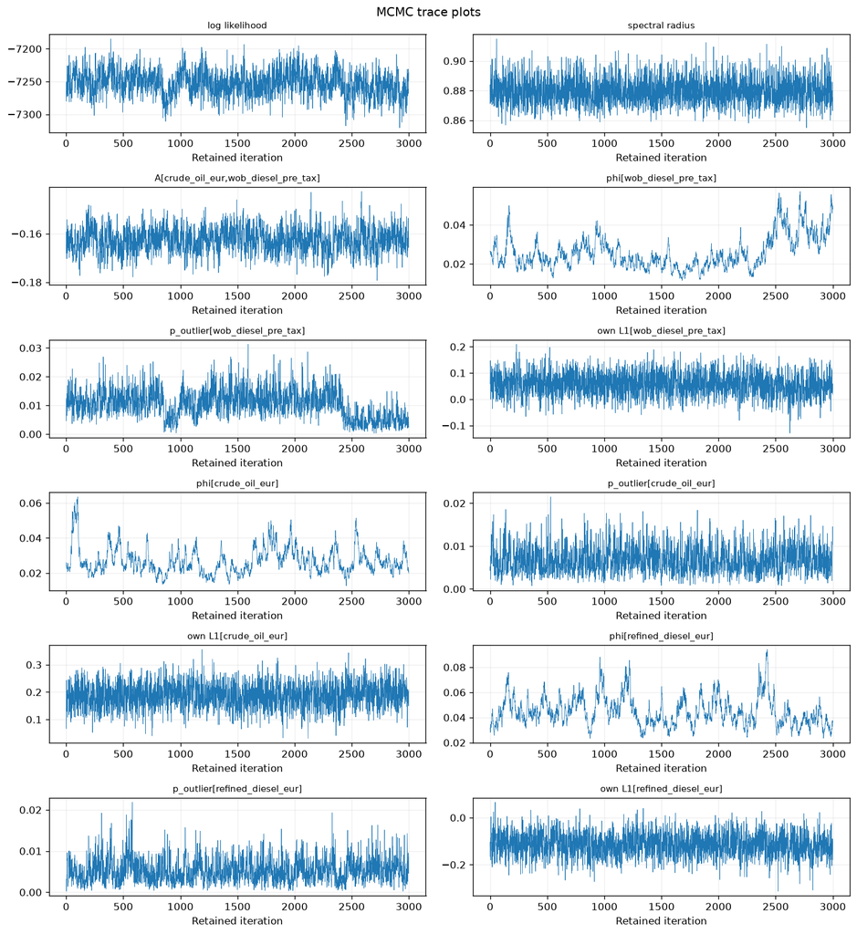

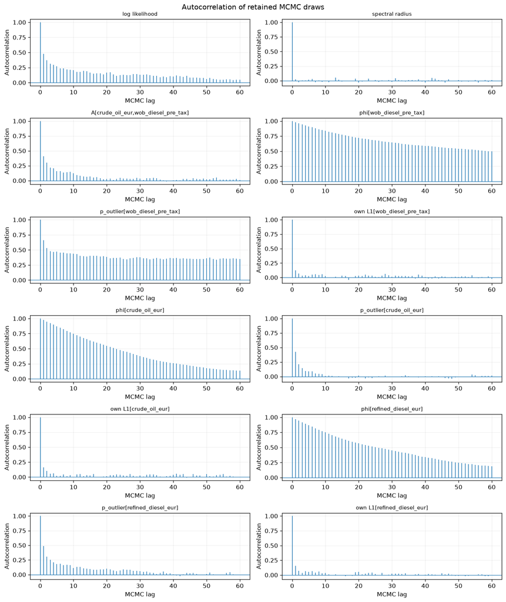

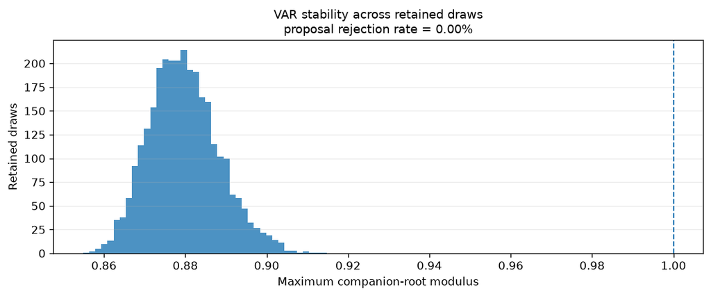

```python
display(style_numeric_table(
    mcmc_diagnostics(result),
    caption="MCMC diagnostics",
))
display(style_numeric_table(
    stability_diagnostics(result).to_frame("value"),
    caption="VAR stability diagnostics",
))
plot_trace_grid(result)
plt.show()
plot_chain_acf_grid(result, nlags=60)
plt.show()
plot_spectral_radius(result)
plt.show()
```

Largest posterior outlier probabilities

| date | wob_diesel_pre_tax | crude_oil_eur | refined_diesel_eur |
| --- | --- | --- | --- |
| 2026-03-09 | 0.99 | 0.94 | 6.00 × 10⁻³ |
| 2022-03-21 | 0.78 | 0.10 | 0.80 |
| 2022-03-14 | 0.77 | 0.99 | 0.58 |
| 2022-03-07 | 0.76 | 2.00 × 10⁻³ | 3.33 × 10⁻⁴ |
| 2022-04-04 | 0.73 | 5.00 × 10⁻³ | 1.33 × 10⁻³ |
| 2022-03-28 | 0.73 | 1.33 × 10⁻³ | 0.15 |
| 2020-03-16 | 0.64 | 0.66 | 8.00 × 10⁻³ |
| 2019-06-10 | 0.23 | 3.00 × 10⁻³ | 2.67 × 10⁻³ |
| 2015-02-09 | 0.22 | 5.33 × 10⁻³ | 2.00 × 10⁻³ |
| 2011-05-09 | 0.16 | 1.00 × 10⁻³ | 0.03 |
| 2025-06-23 | 0.14 | 2.33 × 10⁻³ | 3.33 × 10⁻³ |
| 2009-01-12 | 0.12 | 2.33 × 10⁻³ | 6.67 × 10⁻⁴ |
| 2007-04-02 | 0.10 | 3.33 × 10⁻⁴ | 1.00 × 10⁻³ |
| 2022-06-06 | 0.09 | 1.67 × 10⁻³ | 2.33 × 10⁻³ |
| 2011-06-27 | 0.09 | 2.00 × 10⁻³ | 6.67 × 10⁻⁴ |

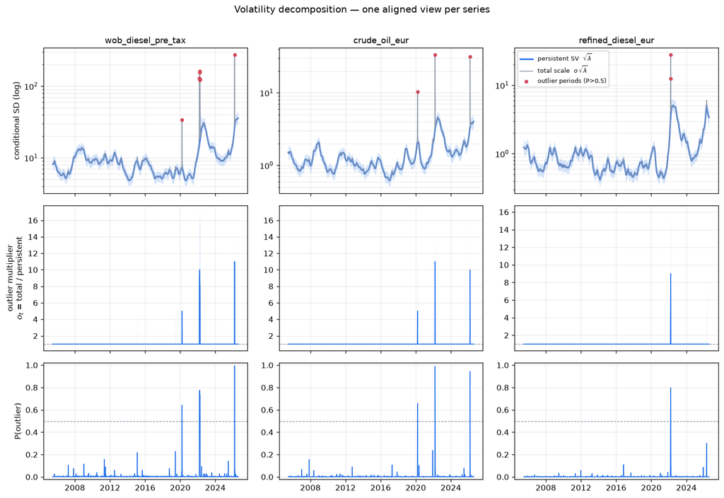

Standardized structural-residual diagnostics

| variable | mean | sd | skewness | excess_kurtosis | acf_1 | maximum_absolute |
| --- | --- | --- | --- | --- | --- | --- |
| wob_diesel_pre_tax | -5.11 × 10⁻⁴ | 0.98 | 0.10 | -0.11 | 0.03 | 3.01 |
| crude_oil_eur | -9.69 × 10⁻³ | 0.97 | -0.14 | -0.15 | -0.02 | 3.08 |
| refined_diesel_eur | -3.09 × 10⁻³ | 0.96 | -0.12 | -0.24 | -0.02 | 3.28 |

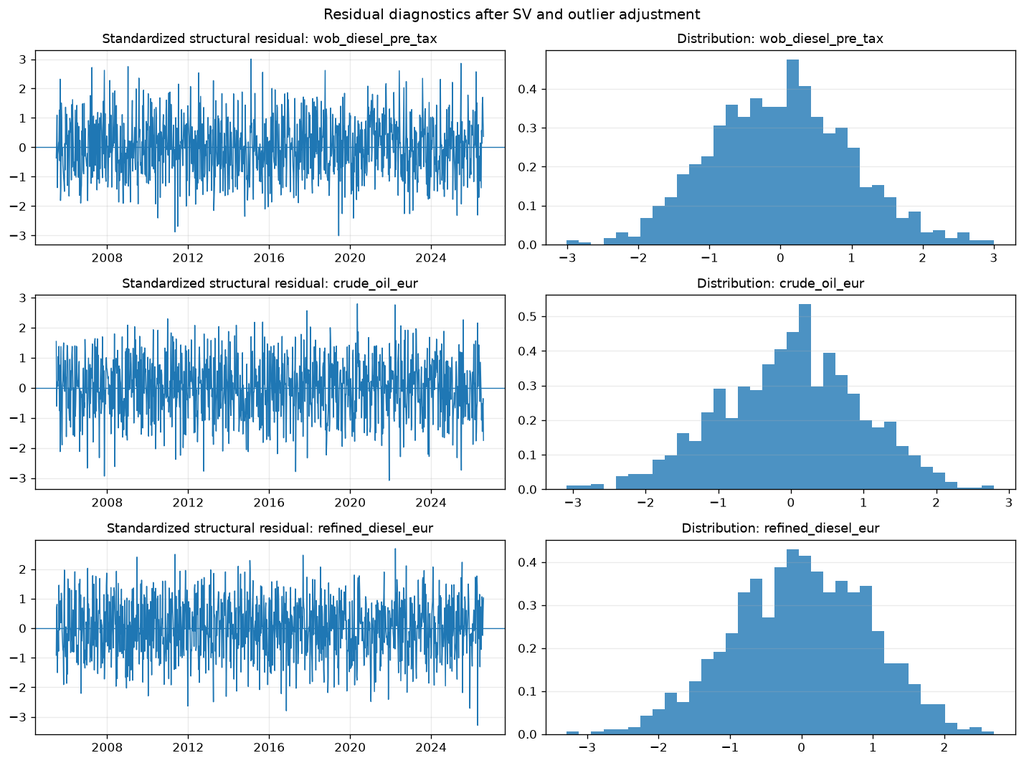

```python
outlier_probability = posterior_outlier_probability(result)
display(style_numeric_table(
    outlier_probability.sort_values(TARGET, ascending=False).head(15),
    caption="Largest posterior outlier probabilities",
))
plot_volatility_decomposition(result)
plt.show()

display(style_numeric_table(
    residual_diagnostic_table(result),
    caption="Standardized structural-residual diagnostics",
))
plot_standardized_residuals(result)
plt.show()
```

Posterior predictive checks

|  | observed | replicated_median | replicated_q05 | replicated_q95 |
| --- | --- | --- | --- | --- |
| wob_diesel_pre_tax: mean | 0.67 | 0.65 | -1.70 | 2.59 |
| wob_diesel_pre_tax: sd | 17.86 | 22.45 | 16.27 | 37.78 |
| wob_diesel_pre_tax: maximum_absolute | 215.90 | 371.64 | 140.78 | 844.68 |
| crude_oil_eur: mean | 0.03 | 0.06 | -0.21 | 0.32 |
| crude_oil_eur: sd | 2.47 | 3.98 | 3.05 | 6.44 |
| crude_oil_eur: maximum_absolute | 17.23 | 70.43 | 29.16 | 163.43 |
| refined_diesel_eur: mean | 0.08 | 0.08 | -0.27 | 0.42 |
| refined_diesel_eur: sd | 4.16 | 4.97 | 3.77 | 8.00 |
| refined_diesel_eur: maximum_absolute | 48.32 | 84.82 | 39.54 | 195.55 |

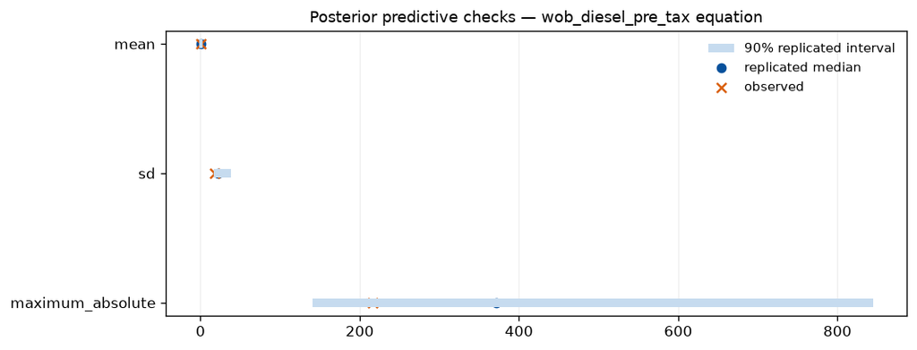

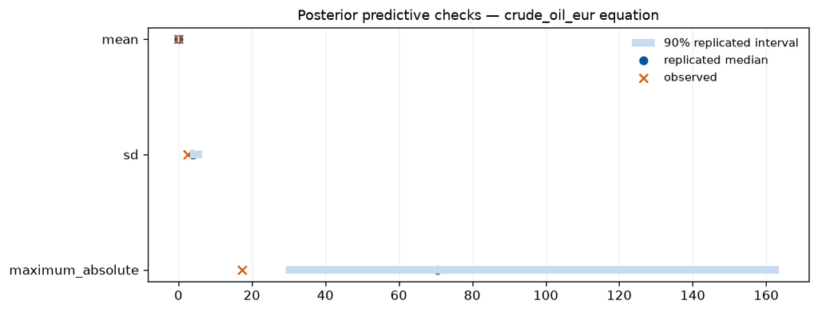

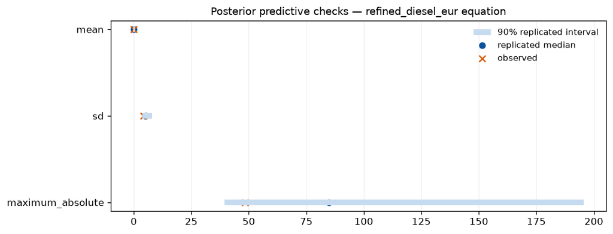

Stationarity tests on posterior-median completed weekly changes

| variable | ADF statistic | ADF p-value | ADF lags | KPSS statistic | KPSS p-value | KPSS lags | observations |
| --- | --- | --- | --- | --- | --- | --- | --- |
| wob_diesel_pre_tax | -6.79 | 2.35 × 10⁻⁹ | 17.00 | 0.08 | 0.10 | 9.00 | 1108.00 |
| crude_oil_eur | -10.02 | 1.69 × 10⁻¹⁷ | 12.00 | 0.05 | 0.10 | 5.00 | 1113.00 |
| refined_diesel_eur | -7.48 | 4.71 × 10⁻¹¹ | 17.00 | 0.07 | 0.10 | 1.00 | 1108.00 |

```python
ppc_summary, ppc_draws = posterior_predictive_statistics(
    result,
    n_draws=PPC_DRAWS,
    seed=456,
)
display(style_numeric_table(
    ppc_summary,
    caption="Posterior predictive checks",
))
for equation in VARIABLES:
    plot_posterior_predictive_check(ppc_summary, equation=equation)
    plt.show()

completed_changes = posterior_completed_differences(result, statistic="median")
display(style_numeric_table(
    stationarity_tests(completed_changes),
    caption="Stationarity tests on posterior-median completed weekly changes",
))

if "missing_level_draws" in result and result["missing_level_draws"].shape[1]:
    q = np.percentile(result["missing_level_draws"], [5, 16, 50, 84, 95], axis=0)
    positions = result["missing_level_positions"]
    imputed_summary = pd.DataFrame({
        "date": [item[0] for item in positions],
        "variable": [item[1] for item in positions],
        "q05": q[0],
        "q16": q[1],
        "median": q[2],
        "q84": q[3],
        "q95": q[4],
        "posterior_sd": np.std(result["missing_level_draws"], axis=0, ddof=1),
    }).set_index(["date", "variable"])
    display(style_numeric_table(
        imputed_summary,
        caption="Posterior draws for internally missing weekly levels",
    ))
```

## 6. Ragged-edge nowcast and weekly forecast

Ragged-edge diesel nowcast

| date | status | observed | q05 | q16 | median | q84 | q95 |
| --- | --- | --- | --- | --- | --- | --- | --- |
| 2026-08-10 | nowcast | — | 1154.48 | 1166.91 | 1187.12 | 1205.22 | 1221.56 |

Weekly diesel pre-tax forecast

| horizon | weeks_ahead | target_date | q05 | q16 | median | q84 | q95 |
| --- | --- | --- | --- | --- | --- | --- | --- |
| 1 week | 1.00 | 2026-08-17 | 1087.56 | 1124.65 | 1167.27 | 1209.78 | 1241.84 |
| 4 weeks | 4.00 | 2026-09-07 | 927.13 | 1032.73 | 1161.14 | 1279.54 | 1395.60 |
| 13 weeks | 13.00 | 2026-11-09 | 647.57 | 928.22 | 1167.19 | 1458.79 | 1747.04 |
| 26 weeks | 26.00 | 2027-02-08 | 235.62 | 730.24 | 1177.81 | 1630.22 | 1996.09 |

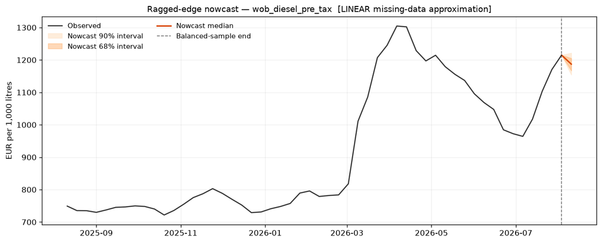

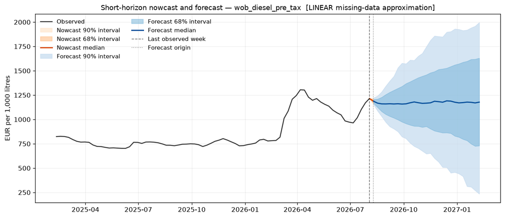

```
Saved unconditional forecast store: C:\Users\kelyan.gane\Project\Python\Bayesian_model\bvar-energy\results\car_fuels_diesel\20260808\aae4c3189fe304e9b1d5e043ea6653dc07a38bdb89b41b044c8315d5f274217d\forecasts\unconditional
```

```python
forecast_unconditional = forecast_bvar_sv_outlier(
    result,
    H=FORECAST_H,
    n_draws=FORECAST_DRAWS,
    simulate_future_outliers=SIMULATE_FUTURE_OUTLIERS,
    seed=123,
)

display(style_numeric_table(
    nowcast_summary_table(
        forecast_unconditional,
        observed_levels=levels,
        variable=TARGET,
    ),
    caption="Ragged-edge diesel nowcast",
))
display(style_numeric_table(
    weekly_forecast_horizon_table(
        forecast_unconditional,
        TARGET,
        horizons=(1, 4, 13, 26),
    ),
    caption="Weekly diesel pre-tax forecast",
))

plot_nowcast_fan(
    forecast_unconditional,
    levels,
    TARGET,
    last_obs=52,
    ylabel=UNITS[TARGET],
)
plt.show()
plot_short_forecast_fan(
    forecast_unconditional,
    levels,
    TARGET,
    last_obs=78,
    ylabel=UNITS[TARGET],
)
plt.show()

if SAVE_FORECASTS:
    saved_forecast_paths = save_energy_bvar_forecast_for_result(
        forecast_unconditional,
        result,
        RESULTS_ROOT,
        "unconditional",
    )
    print(f"Saved unconditional forecast store: {saved_forecast_paths['directory']}")
```